# **Proyecto - Diplomado Inteligencia de Negocios 2024**

Integrantes:

- Rolando Serrano L.
- Diego Leiva E.
- Daniel Ruminado L.

Fecha de entrega: Domingo, 10 de Noviembre a las 23:59 hrs.

## **Descipción del dataset**

De acuerdo con lo anterior, es necesario responder a las siguientes interrogantes expuestas por el gerente general:

1. ¿Cuáles son las acciones comerciales que deberíamos emprender con estos clientes?

> > **Respueta: Basándonos en esto, las acciones comerciales recomendadas serían: a) Desarrollar un modelo predictivo preciso para identificar a los clientes con mayor probabilidad de fuga. b) Para los clientes identificados como de alto riesgo de fuga, implementar campañas de retención personalizadas y realizar seguimiento y atención prioritaria c) Mejorar continuamente el servicio al cliente y la experiencia general para todos los clientes, lo que puede ayudar a prevenir fugas futuras.**
2. ¿Se deben aplicar estas medidas a todos los clientes? Una completa descripción de las variables recolectadas por cada cliente se presenta a continuación:

Una completa descripción de las variables recolectadas por cada cliente se presenta a continuación:

- **ID:** Identificador del cliente
- **Genero:** Genero del cliente
- **Renta:** Renta en pesos (estimada)
- **Edad:** Edad en años
- **NIV_Educ:** Nivel educacional
- **E_Civil:** Estado civil
- **COD_Ofi:** Código de la oficina
- **COD_Com:** Código de la comuna
- **Ciudad:** Ciudad de la oficina
- **D_Marzo:** Deuda de Marzo
- **D_Abril:** Deuda de Abril
- **D_Mayo:** Deuda de Mayo
- **D_Junio:** Deuda de Junio
- **D_Julio:** Deuda de Julio
- **D_Agosto:** Deuda de Agosto
- **D_Septiembre:** Deuda de Septiembre
- **M_Moroso:** Nº de veces que el cliente ha estado en mora (históricamente)
- **Monto:** Monto crédito preaprobado
- **Seguro:** Seguro de gravamen contratado
- **Fuga:** Variable objetivo

Las variables de deuda para los meses descritos indican la deuda facturada durante ese mes, por tanto, no necesariamente la deuda vigente es la suma de las deudas por mes.

El primer archivo llamado BASEFUGA_GENERAL, contiene los datos con la variable dependiente indicando si se fugó o no el cliente. El segundo archivo llamado BASEFUGA_PREDICCION, provee de otro conjunto con 1.200 clientes descritos por las mismas variables, salvo que no se conoce si se fugaron o no.

Resultados Esperados

1. Desarrollo de un modelo predictivo de fugas que maximice el beneficio esperado.
2. Definir el patrón característico de los clientes fugitivos y de los clientes no fugitivos.
3. Sugerencia de al menos tres acciones comerciales a emprender con los clientes que el modelo indique (se valorará la sensatez comercial y lo efectivas que estas puedan ser para evitar la fuga).
4. Predicción del conjunto BASEFUGA_PREDICCION (la no entrega de estos resultados significa una penalización de 0.5 puntos en la nota final).

Para la tarea se les pide:

1. Indicar qué problemas detecta en la base de datos y medidas para corregirlos. Debe indicar el procedimiento que siguió para resolverlos de forma clara y precisa.
2. Realizar un análisis descriptivo de los datos. En este punto deben explorar y presentan sus hayazgos para una mejor comprensión de los datos, por ejemplo, estadísticas descriptivas, tablas de frecuencia, etc. Apoye su análisis utilizando gráficos.
3. Transformar datos y generar indicadores: transforme las variables disponibles de forma de encontrar nuevas variables, generadas a partir de las originales, que puedan tener un buen desempeño predictivo a partir de sus conocimientos del negocio.
4. Seleccionar atributos: analice sus variables de la base. ¿Discriminan entre clientes fugados y no fugados?.
5. Modelación de Minería de Datos: entrene al menos 3 modelos predictivos. Algunos candidatos son: regresión logística, KNN, árboles de decisión y SVM. No obstante, también puede utilizar modelos cuya implementación no hayamos visto en el programa. Describa el proceso de validación y selección del modelo para cada caso. Describa las soluciones encontradas en términos de las variables presentes y coeficientes. Aplique este modelo al conjunto de datos de predicción. Escriba un reporte en el mismo notebook donde desarrolle los análisis para su jefatura, documentando cada etapa del procedimiento desarrollado para generar esta base de datos y sus recomendaciones. Pauta reporte El informe (en notebook) desarrollado debe contener al menos los siguientes puntos:
6. Nombre de los integrantes e índice.
7. Introducción: se debe dar una descripción general del problema a resolver, una breve descripción del contenido del reporte y una clara visualización de objetivos, tanto generales como específicos (todo lo referido a la documentación debe ser desarrollado en markdown).
8. Análisis estadístico de los datos
9. Modelos de Minería de Datos: no olvidar la descripción de parámetros de ajuste respecto a la medida de performance (beneficios esperados).
10. Determinar el mejor modelo de clasificación utilizando como criterio el máximo beneficio y definición del patrón característico de los clientes fugas y no fugas.
11. Políticas comerciales, conclusiones y discusiones.

Condiciones de la tarea:

● Debe ser desarrollada en grupos de 1 a 3 personas.

● El software a utilizar será Python en Jupyter Notebook.

● Se pide un reporte totalmente autocontenido en Jupyter y un archivo formato .csv con la predicción para todas las observaciones del conjunto de BASEFUGA_PREDICCION. El mejor grupo tendrá una bonificación de 0,5 puntos en la nota de esta tarea.

● La fecha de entrega será la estipulada en u-cursos.

## **Configuración del entorno**

```python
# manejo de datos
import numpy as np
import pandas as pd

# metricas
from sklearn.metrics import recall_score, precision_score, accuracy_score
from sklearn.metrics import classification_report, confusion_matrix

# visualización
import matplotlib.pyplot as plt
import seaborn as sns


#machine learning
from sklearn.model_selection import train_test_split
from sklearn.linear_model import LogisticRegression
from sklearn.ensemble import RandomForestClassifier
from sklearn.svm import SVC
from sklearn.metrics import accuracy_score, precision_score, recall_score, f1_score, roc_auc_score
from sklearn.model_selection import GridSearchCV
```

## Lectura de los DataFrame

```python
#BASEFUGA_GENERAL

data = pd.read_csv("https://raw.githubusercontent.com/ssantanar/datasets/master/fuga/BASEFUGA_GENERAL.csv")
print(data.shape)
data.head()
```

```
(2294, 20)
```

|  | ID | GENERO | RENTA | EDAD | NIV_EDUC | E_CIVIL | COD_OFI | COD_COM | CIUDAD | D_Marzo | D_Abril | D_Mayo | D_Junio | D_Julio | D_Agosto | D_Septiembre | M_MOROSO | MONTO | SEGURO | FUGA |
| --- | --- | --- | --- | --- | --- | --- | --- | --- | --- | --- | --- | --- | --- | --- | --- | --- | --- | --- | --- | --- |
| 0 | 1 | M | 746476 | 39.0 | MED | CAS | 68 | 213.0 | LOS ANGELES | 0 | 38292 | 0 | 434357 | 1766 | 9110 | 340 | 2 | 2000000 | NO | NO FUGA |
| 1 | 2 | F | 11901 | 49.0 | MED | VIU | 16 | 89.0 | SANTIAGO | 0 | 0 | 0 | 0 | 48 | 0 | 0 | 1 | 7500000 | SI | NO FUGA |
| 2 | 3 | M | 1651421 | 39.0 | TEC | CAS | 90 | 16.0 | ANTOFAGASTA | 0 | 604169 | 0 | 0 | 323 | 26489 | 2925 | 1 | 8000000 | NO | NO FUGA |
| 3 | 4 | F | 638969 | 36.0 | UNV | CAS | 85 | 115.0 | SANTIAGO | 0 | 5125 | 0 | 198998 | 94 | 0 | 105 | 1 | 2600000 | NO | NO FUGA |
| 4 | 5 | M | 860113 | 44.0 | TEC | CAS | 45 | 80.0 | SANTIAGO | 0 | 11946 | 0 | 73959 | 149 | 0 | 272 | 1 | 6400000 | NO | NO FUGA |

El DataFrame cuenta con 2294 registros y 20 columnas, siendo la columna "FUGA" nuestra variable objetivo.

```python
#BASEFUGA_VALIDACION

data_validacion = pd.read_csv("https://raw.githubusercontent.com/ssantanar/datasets/master/fuga/BASEFUGA_VALIDACION.csv", sep=';')
print(f"Filas: {len(data_validacion)}")
data_validacion.head()
```

```
Filas: 1200
```

|  | ID | GENERO | RENTA | EDAD | NIV_EDUC | E_CIVIL | COD_OFI | COD_COM | CIUDAD | D_Marzo | D_Abril | D_Mayo | D_Junio | D_Julio | D_Agosto | D_Septiembre | M_MOROSO | MONTO | SEGURO | FUGA |
| --- | --- | --- | --- | --- | --- | --- | --- | --- | --- | --- | --- | --- | --- | --- | --- | --- | --- | --- | --- | --- |
| 0 | 2295 | M | 457693.0 | 45 | UNV | CAS | 31 | 119.0 | SANTIAGO | 0 | 190591 | 0 | 20396 | 0 | 0 | 415 | 1.0 | 2700000 | NO | NaN |
| 1 | 2296 | F | 2258382.0 | 30 | TEC | SOL | 74 | 272.0 | VALDIVIA | 0 | 47354 | 0 | 0 | 0 | 0 | 2 | 0.0 | 1900000 | NO | NaN |
| 2 | 2297 | M | 546190.0 | 51 | UNV | CAS | 138 | 1.0 | ARICA | 622808 | 61646 | 0 | 268771 | 235 | 2913 | 0 | 1.0 | 1100000 | SI | NaN |
| 3 | 2298 | F | 424424.0 | 41 | MED | SOL | 138 | 80.0 | SANTIAGO | 0 | 1054 | 0 | 392871 | 1961 | 0 | 1022 | 3.0 | 3500000 | NO | NaN |
| 4 | 2299 | M | 6862726.0 | 42 | MED | CAS | 52 | 91.0 | SANTIAGO | 0 | 264308 | 0 | 87931 | 74 | 0 | 38 | 1.0 | 2000000 | NO | NaN |

## **1. Análisis Exploratorio de Datos (EDA) Inspección de datos perdidos y outliers**

### 1.1 Datos perdidos

```python
# contar missing values

print(data.isna().sum())
```

```
ID               0
GENERO          11
RENTA            0
EDAD             2
NIV_EDUC        11
E_CIVIL         11
COD_OFI          0
COD_COM          3
CIUDAD           3
D_Marzo          0
D_Abril          0
D_Mayo           0
D_Junio          0
D_Julio          0
D_Agosto         0
D_Septiembre     0
M_MOROSO         0
MONTO            0
SEGURO           0
FUGA             0
dtype: int64
```

Las siguientes columnas tienen valores perdidos:

- GENERO: 11
- EDAD: 2
- NIV_EDUC: 11
- E_CIVIL: 11
- COD_COM: 3
- CIUDAD: 3

Existen 6 columnas que contienen al menos un valor perdido. Los valores perdidos en total son 41.

```python
# Filas con algun valor perdido

data[data.isnull().any(axis=1)]
```

|  | ID | GENERO | RENTA | EDAD | NIV_EDUC | E_CIVIL | COD_OFI | COD_COM | CIUDAD | D_Marzo | D_Abril | D_Mayo | D_Junio | D_Julio | D_Agosto | D_Septiembre | M_MOROSO | MONTO | SEGURO | FUGA |
| --- | --- | --- | --- | --- | --- | --- | --- | --- | --- | --- | --- | --- | --- | --- | --- | --- | --- | --- | --- | --- |
| 17 | 18 | M | 808822 | NaN | UNV | CAS | 31 | 119.0 | SANTIAGO | 0 | 14243 | 0 | 0 | 147 | 0 | 0 | 2 | 4500000 | NO | FUGA |
| 30 | 31 | NaN | 1126011 | 37.0 | TEC | CAS | 52 | 86.0 | SANTIAGO | 0 | 533076 | 0 | 0 | 0 | 17581 | 0 | 0 | 8000000 | NO | NO FUGA |
| 217 | 218 | M | 286587 | 46.0 | UNV | NaN | 31 | 119.0 | SANTIAGO | 0 | 4857 | 0 | 306010 | 411 | 0 | 341 | 1 | 1900000 | NO | FUGA |
| 238 | 239 | NaN | 69049 | 38.0 | MED | CAS | 129 | 88.0 | SANTIAGO | 0 | 952303 | 0 | 0 | 8 | 0 | 15 | 2 | 8000000 | SI | NO FUGA |
| 263 | 264 | F | 91397 | 49.0 | MED | CAS | 45 | NaN | NaN | 0 | 58355 | 0 | 0 | 33 | 19746 | 0 | 1 | 6500000 | NO | NO FUGA |
| 279 | 280 | M | 187937 | 35.0 | UNV | CAS | 90 | NaN | NaN | 0 | 0 | 0 | 0 | 1025 | 6588 | 0 | 1 | 1200000 | NO | NO FUGA |
| 298 | 299 | M | 360151 | 54.0 | UNV | NaN | 122 | 516.0 | LLO-LLEO | 0 | 0 | 0 | 0 | 0 | 779 | 0 | 0 | 2000000 | NO | NO FUGA |
| 377 | 378 | NaN | 157575 | 24.0 | UNV | SOL | 80 | 89.0 | SANTIAGO | 108319 | 51212 | 0 | 140973 | 667 | 0 | 1 | 1 | 1200000 | NO | FUGA |
| 387 | 388 | F | 23677 | 28.0 | TEC | NaN | 25 | 93.0 | SANTIAGO | 0 | 142242 | 0 | 30344 | 104 | 0 | 26 | 1 | 2200000 | NO | FUGA |
| 397 | 398 | F | 391269 | 50.0 | UNV | NaN | 131 | 94.0 | SANTIAGO | 0 | 262714 | 0 | 0 | 0 | 127 | 0 | 1 | 1200000 | SI | FUGA |
| 469 | 470 | F | 15734 | 41.0 | TEC | NaN | 83 | 89.0 | SANTIAGO | 0 | 625214 | 0 | 0 | 0 | 2552 | 450 | 0 | 5400000 | NO | NO FUGA |
| 506 | 507 | NaN | 352567 | 33.0 | MED | SOL | 124 | 253.0 | TEMUCO | 0 | 446536 | 0 | 781373 | 1179 | 0 | 3267 | 1 | 2200000 | NO | NO FUGA |
| 712 | 713 | M | 237944 | 29.0 | NaN | CAS | 76 | 104.0 | SANTIAGO | 45468 | 30231 | 0 | 580777 | 557 | 0 | 456 | 1 | 2900000 | NO | NO FUGA |
| 734 | 735 | M | 3934515 | 40.0 | NaN | CAS | 76 | 98.0 | SANTIAGO | 0 | 5986 | 583734 | 33859 | 10 | 0 | 676 | 1 | 3700000 | SI | FUGA |
| 794 | 795 | F | 1685802 | 38.0 | UNV | NaN | 21 | 502.0 | CHUQUICAMATA | 0 | 124325 | 0 | 0 | 42 | 0 | 0 | 1 | 8000000 | NO | NO FUGA |
| 796 | 797 | M | 15383 | 52.0 | MED | NaN | 27 | 226.0 | CONCEPCION | 0 | 18093 | 0 | 44664 | 465 | 6804 | 1625 | 2 | 4200000 | NO | FUGA |
| 894 | 895 | M | 1353803 | 44.0 | NaN | CAS | 88 | 67.0 | VINA DEL MAR | 0 | 2629477 | 0 | 198382 | 2 | 0 | 0 | 1 | 8000000 | NO | NO FUGA |
| 1004 | 1005 | NaN | 1021034 | 44.0 | TEC | CAS | 55 | 86.0 | SANTIAGO | 0 | 19790 | 0 | 0 | 0 | 0 | 2 | 1 | 8000000 | NO | NO FUGA |
| 1014 | 1015 | M | 564286 | 49.0 | UNV | VIU | 45 | NaN | NaN | 0 | 344228 | 0 | 0 | 0 | 23101 | 0 | 1 | 6500000 | NO | NO FUGA |
| 1018 | 1019 | NaN | 45462 | 46.0 | UNV | CAS | 73 | 80.0 | SANTIAGO | 0 | 783528 | 0 | 0 | 0 | 13497 | 0 | 0 | 2800000 | NO | NO FUGA |
| 1075 | 1076 | M | 82084 | 49.0 | TEC | NaN | 121 | 87.0 | SANTIAGO | 1022555 | 391225 | 0 | 0 | 908 | 15808 | 11 | 2 | 5000000 | NO | NO FUGA |
| 1133 | 1134 | M | 230916 | 52.0 | NaN | SOL | 18 | 93.0 | SANTIAGO | 0 | 507276 | 0 | 90814 | 981 | 0 | 0 | 1 | 3800000 | NO | FUGA |
| 1334 | 1335 | NaN | 115805 | 49.0 | UNV | CAS | 86 | 49.0 | LOS ANDES | 560762 | 0 | 0 | 0 | 356 | 5665 | 0 | 1 | 1500000 | NO | NO FUGA |
| 1407 | 1408 | M | 1856518 | 53.0 | UNV | NaN | 27 | 226.0 | CONCEPCION | 0 | 1485962 | 0 | 138238 | 0 | 1997 | 0 | 1 | 8000000 | NO | FUGA |
| 1432 | 1433 | M | 843643 | 53.0 | UNV | NaN | 138 | 1.0 | ARICA | 89246 | 125992 | 0 | 274086 | 263 | 0 | 607 | 3 | 1000000 | SI | FUGA |
| 1449 | 1450 | M | 238824 | 27.0 | NaN | CAS | 126 | 80.0 | SANTIAGO | 0 | 66467 | 0 | 17710 | 83 | 0 | 0 | 1 | 1800000 | SI | FUGA |
| 1654 | 1655 | F | 422659 | NaN | UNV | CAS | 76 | 80.0 | SANTIAGO | 0 | 370264 | 0 | 0 | 145 | 0 | 634 | 2 | 3600000 | SI | FUGA |
| 1704 | 1705 | NaN | 649038 | 45.0 | UNV | CAS | 31 | 119.0 | SANTIAGO | 2696916 | 798804 | 0 | 75372 | 1603 | 0 | 849 | 1 | 550000 | SI | FUGA |
| 1761 | 1762 | M | 119387 | 41.0 | NaN | SOL | 34 | 29.0 | LA SERENA | 0 | 875758 | 0 | 0 | 1 | 0 | 0 | 1 | 8000000 | NO | NO FUGA |
| 1802 | 1803 | M | 283440 | 48.0 | UNV | NaN | 148 | 90.0 | SANTIAGO | 0 | 124072 | 0 | 0 | 40 | 0 | 0 | 1 | 1900000 | SI | FUGA |
| 2039 | 2040 | F | 201090 | 58.0 | NaN | CAS | 45 | 93.0 | SANTIAGO | 0 | 57238 | 0 | 0 | 168 | 0 | 0 | 1 | 6500000 | SI | NO FUGA |
| 2052 | 2053 | NaN | 405315 | 38.0 | MED | SOL | 56 | 146.0 | DONIHUE | 0 | 12918 | 0 | 21338 | 242 | 0 | 0 | 1 | 1800000 | NO | NO FUGA |
| 2064 | 2065 | NaN | 198319 | 28.0 | TEC | CAS | 27 | 226.0 | CONCEPCION | 0 | 101824 | 0 | 115288 | 0 | 0 | 9 | 1 | 1200000 | NO | FUGA |
| 2066 | 2067 | M | 605736 | 41.0 | NaN | CAS | 144 | 93.0 | SANTIAGO | 0 | 0 | 0 | 0 | 0 | 0 | 1 | 0 | 5000000 | NO | NO FUGA |
| 2150 | 2151 | F | 70772 | 44.0 | NaN | SOL | 148 | 92.0 | SANTIAGO | 0 | 303373 | 0 | 16551 | 175 | 26968 | 183 | 1 | 7400000 | SI | NO FUGA |
| 2192 | 2193 | NaN | 78452 | 27.0 | UNV | SOL | 60 | 291.0 | PUERTO MONTT | 0 | 51 | 0 | 263925 | 96 | 0 | 206 | 1 | 1500000 | NO | NO FUGA |
| 2215 | 2216 | M | 4638 | 41.0 | NaN | CAS | 55 | 90.0 | SANTIAGO | 0 | 17570 | 0 | 96204 | 599 | 11950 | 31 | 1 | 3400000 | NO | FUGA |
| 2265 | 2266 | M | 499746 | 44.0 | NaN | CAS | 31 | 119.0 | SANTIAGO | 1109798 | 13434 | 0 | 186438 | 1334 | 0 | 804 | 1 | 1500000 | SI | FUGA |

```python
# Contar filas con algun valor perdido

data.isnull().any(axis=1).sum()
```

```
38
```

Gracias a la información anterior, podemos observar que existen 38 registros con algun valor perdido.

### 1.2 Describe

```python
data.describe().round(2)
```

|  | ID | RENTA | EDAD | COD_OFI | COD_COM | D_Marzo | D_Abril | D_Mayo | D_Junio | D_Julio | D_Agosto | D_Septiembre | M_MOROSO | MONTO |
| --- | --- | --- | --- | --- | --- | --- | --- | --- | --- | --- | --- | --- | --- | --- |
| count | 2294.00 | 2294.00 | 2292.00 | 2294.00 | 2291.00 | 2294.00 | 2294.00 | 2294.00 | 2294.00 | 2294.00 | 2294.00 | 2294.00 | 2294.00 | 2294.00 |
| mean | 1147.50 | 852756.27 | 43.55 | 68.54 | 107.95 | 153020.64 | 272681.03 | 103231.53 | 189976.06 | 566.85 | 3578.76 | 1940.64 | 1.25 | 3477092.41 |
| std | 662.37 | 1379715.21 | 8.88 | 40.16 | 84.77 | 498187.54 | 402325.69 | 870698.44 | 670504.23 | 1075.33 | 8942.38 | 9868.82 | 0.75 | 2292933.05 |
| min | 1.00 | 176.00 | -50.00 | 0.00 | 1.00 | 0.00 | 0.00 | 0.00 | 0.00 | 0.00 | 0.00 | 0.00 | 0.00 | 500000.00 |
| 25% | 574.25 | 100381.50 | 39.00 | 31.00 | 80.00 | 0.00 | 17674.25 | 0.00 | 0.00 | 7.00 | 0.00 | 0.00 | 1.00 | 1700000.00 |
| 50% | 1147.50 | 369934.50 | 44.00 | 56.00 | 90.00 | 0.00 | 134474.50 | 0.00 | 5502.00 | 146.00 | 0.00 | 56.00 | 1.00 | 2600000.00 |
| 75% | 1720.75 | 826758.25 | 50.00 | 92.00 | 118.00 | 0.00 | 374425.00 | 0.00 | 174906.00 | 629.75 | 1486.25 | 497.25 | 2.00 | 4800000.00 |
| max | 2294.00 | 8454317.00 | 130.00 | 155.00 | 516.00 | 9458161.00 | 5495534.00 | 18396961.00 | 20634612.00 | 11187.00 | 88837.00 | 249652.00 | 3.00 | 8000000.00 |

A partir de la información del describe, podemos observar algunas anomalías en las variables numéricas:

EDAD: Existe una edad mínima de -50, lo cual es imposible, entendiendo que la edad de una persona no puede ser menor a cero. Por otro lado, hay una edad máxima de 130, lo cual es poco probable que ocurra. Si esta anomalía está presente, es posible que dentro de la misma variable existan más de estos elementos.

### 1.3 Análisis datos categóricos

Las variables categóricas del dataset son las siguientes (7):

- GENERO
- NIV_EDUC
- E_CIVIL
- COD_OFI
- COD_COM
- CIUDAD
- SEGURO

#### 1.3.1 Columna 'GENERO'

```python
# Index(['ID', 'GENERO', 'RENTA', 'EDAD', 'NIV_EDUC', 'E_CIVIL',
  # 'COD_OFI', 'COD_COM', 'CIUDAD', 'D_Marzo', 'D_Abril', 'D_Mayo',
  # 'D_Junio','D_Julio', 'D_Agosto', 'D_Septiembre', 'M_MOROSO', 'MONTO', 'SEGURO','FUGA']

data.GENERO.unique()
```

```
array(['M', 'F', nan], dtype=object)
```

Hay 2 géneros identificados: M y F, excluyendo los valores perdidos.

#### 1.3.2 Columna 'NIV_EDUC'

```python
# Index(['ID', 'GENERO', 'RENTA', 'EDAD', 'NIV_EDUC', 'E_CIVIL',
  # 'COD_OFI', 'COD_COM', 'CIUDAD', 'D_Marzo', 'D_Abril', 'D_Mayo',
  # 'D_Junio','D_Julio', 'D_Agosto', 'D_Septiembre', 'M_MOROSO', 'MONTO', 'SEGURO','FUGA']

data.NIV_EDUC.unique()
```

```
array(['MED', 'TEC', 'UNV', 'BAS', nan, 'EUN'], dtype=object)
```

En la columna NIV_EDUC se observan 5 niveles educacionales, excluyendo los valores perdidos.

#### 1.3.3 Columna 'E_CIVIL'

```python
# Index(['ID', 'GENERO', 'RENTA', 'EDAD', 'NIV_EDUC', 'E_CIVIL',
  # 'COD_OFI', 'COD_COM', 'CIUDAD', 'D_Marzo', 'D_Abril', 'D_Mayo',
  # 'D_Junio','D_Julio', 'D_Agosto', 'D_Septiembre', 'M_MOROSO', 'MONTO', 'SEGURO','FUGA']

data.E_CIVIL.unique()
```

```
array(['CAS', 'VIU', 'SOL', 'SEP', nan], dtype=object)
```

En la columna E_CIVIL, se identificar 4 estados civiles, excluyendo los valores perdidos.

#### 1.3.4 Columna 'COD_OFI'

```python
# Index(['ID', 'GENERO', 'RENTA', 'EDAD', 'NIV_EDUC', 'E_CIVIL',
  # 'COD_OFI', 'COD_COM', 'CIUDAD', 'D_Marzo', 'D_Abril', 'D_Mayo',
  # 'D_Junio','D_Julio', 'D_Agosto', 'D_Septiembre', 'M_MOROSO', 'MONTO', 'SEGURO','FUGA']

data.COD_OFI.unique()
```

```
array([ 68,  16,  90,  85,  45,  53,  55,  47,  22,  27,  41, 139,  52,
       122,  80, 128,  31, 152,  19, 138,  77,  13,  60, 116,  92, 102,
       124, 125,  37,  21, 127,  30, 123,  12,  24,  25,  20,  84,  29,
       104,  18, 149, 101,  73,  15,  40,  34, 100,  76, 120,  61,  74,
        10,  83,  39,  54,  98, 126,  32,  57,  69,  56, 108, 118,  63,
        67,  50,  14, 129,  48,  78,  66,  51,  59,  72,  64, 130,  88,
        94,  42,  70, 107,  49,  44, 151, 103,  38, 153,  79,  35,  43,
       144,  71,  81, 141,   0, 132, 131, 142,  96,  17, 105, 134,  86,
        82,  75,  95,  91, 140,  93,  23,  62,  87,  46,  28, 117,  11,
       121, 146,  65,  33, 155, 147,  36,  89, 148])
```

A partir del contenido de la columna 'COD_OFI', se observa que existe un número que sirve para identificaar una determinada oficina.

```python
#Identificar en cuántos registros hay un codigo de oficina cero

data[data['COD_OFI'] == 0]
```

|  | ID | GENERO | RENTA | EDAD | NIV_EDUC | E_CIVIL | COD_OFI | COD_COM | CIUDAD | D_Marzo | D_Abril | D_Mayo | D_Junio | D_Julio | D_Agosto | D_Septiembre | M_MOROSO | MONTO | SEGURO | FUGA |
| --- | --- | --- | --- | --- | --- | --- | --- | --- | --- | --- | --- | --- | --- | --- | --- | --- | --- | --- | --- | --- |
| 372 | 373 | F | 15785 | 56.0 | TEC | SOL | 0 | 66.0 | VALPARAISO | 0 | 591546 | 0 | 0 | 0 | 540 | 599 | 0 | 1300000 | SI | NO FUGA |

Entendiendo que hay un identificador numérico para cada código de oficina, es posible que exista una con código '0', a pesar de estar presente en solo un registro.

#### 1.3.5 Columna 'CIUDAD'

```python
# Index(['ID', 'GENERO', 'RENTA', 'EDAD', 'NIV_EDUC', 'E_CIVIL',
  # 'COD_OFI', 'COD_COM', 'CIUDAD', 'D_Marzo', 'D_Abril', 'D_Mayo',
  # 'D_Junio','D_Julio', 'D_Agosto', 'D_Septiembre', 'M_MOROSO', 'MONTO', 'SEGURO','FUGA']

data.CIUDAD.unique()
```

```
array(['LOS ANGELES', 'SANTIAGO', 'ANTOFAGASTA', 'ARICA', 'CONCEPCION',
       'TALCAHUANO', 'TEMUCO', 'RANCAGUA', 'CHUQUICAMATA', 'PUERTO OCTAY',
       'CALAMA', 'PUNTA ARENAS', 'CON-CON', 'VLLA ALEMANA', 'OSORNO',
       'IQUIQUE', 'VINA DEL MAR', 'TALAGANTE', 'LA SERENA', 'SAN FELIPE',
       'RENGO', 'CASTRO', 'CHILLAN', 'COLBUN', 'PENAFLOR', 'VALDIVIA',
       'EL SALVADOR', 'COYHAIQUE', 'ANCUD', 'COQUIMBO', 'LONCOCHE',
       'CURICO', 'LOS ANDES', 'SAN CLEMENTE', nan, 'PALENA', 'LLANQUIHUE',
       'LLO-LLEO', 'SAN PABLO', 'QUILPUE', 'CALDERA', 'MELIPILLA',
       'TALCA', 'SAN FERNANDO', 'PUERTO MONTT', 'QUILLOTA', 'VALPARAISO',
       'LA CALERA', 'STO DOMINGO', 'CURACAVI', 'AYSEN', 'LOS VILOS',
       'PANGUIPULLI', 'CORONEL', 'COPIAPO', 'PUERTO VARAS', 'LINARES',
       'SAN PEDRO', 'TOCOPILLA', 'ANGOL', 'PARRAL', 'SAN ESTEBAN',
       'HIJUELAS', 'SAN ANTONIO', 'MACHALI', 'VALLENAR', 'CALBUCO',
       'SANTA CRUZ', 'HUASCO', 'LOS LAGOS', 'VILLARRICA', 'LA CRUZ',
       'PETORCA', 'OVALLE', 'DONIHUE', 'PENCO'], dtype=object)
```

En la variable 'CIUDAD', hay diferentes nombres de ciudades de Chile. No se observa ninguna anomalía, a excepción del valor perdido.

```python
# Contamos los valores por categoría

cuenta_ciudad = data['CIUDAD'].value_counts()
print(cuenta_ciudad)
```

```
CIUDAD
SANTIAGO        1389
ARICA            234
CONCEPCION       152
ANTOFAGASTA       47
VINA DEL MAR      42
                ...
CORONEL            1
LOS VILOS          1
PALENA             1
SAN CLEMENTE       1
PENCO              1
Name: count, Length: 75, dtype: int64
```

La mayoría de los clientes de encuentran en la ciudad de Santiago, seguido de Arica y Concepción.

#### 1.3.6 Columna 'SEGURO'

```python
# Index(['ID', 'GENERO', 'RENTA', 'EDAD', 'NIV_EDUC', 'E_CIVIL',
  # 'COD_OFI', 'COD_COM', 'CIUDAD', 'D_Marzo', 'D_Abril', 'D_Mayo',
  # 'D_Junio','D_Julio', 'D_Agosto', 'D_Septiembre', 'M_MOROSO', 'MONTO', 'SEGURO','FUGA']

data.SEGURO.unique()
```

```
array(['NO', 'SI'], dtype=object)
```

La variable 'SEGURO' posee 2 categorías: SI y NO, lo cual hace referencia al contrato de un Seguro de gravamen. No contiene valores perdidos.

#### 1.3.7 Columna 'COD_COM'

```python
# Index(['ID', 'GENERO', 'RENTA', 'EDAD', 'NIV_EDUC', 'E_CIVIL',
  # 'COD_OFI', 'COD_COM', 'CIUDAD', 'D_Marzo', 'D_Abril', 'D_Mayo',
data.COD_COM.unique()
```

```
array([213.,  89.,  16., 115.,  80.,  92.,  90., 112.,   1., 103.,  93.,
       105., 110.,  88., 119.,  85., 226., 227., 108., 253.,  86., 131.,
        87.,  98., 502., 104., 287.,  13., 100., 326.,  83., 513.,  71.,
        96., 113., 284.,  91.,   5., 118.,  67.,  84., 127.,  95.,  29.,
        53., 138., 300., 193., 106., 184., 128., 272.,  97., 504., 314.,
        81., 111., 301.,  31., 265., 164.,  49., 176.,  nan,  82., 117.,
       313., 298., 516., 285.,  70.,  23., 122., 173., 148., 291.,  59.,
        66., 101.,  94.,  61.,  79., 511., 124., 316.,  99.,  42., 279.,
       102., 120., 234.,  22., 292., 182., 126.,  11., 116., 242., 186.,
        50., 107.,  63.,  74., 121., 135.,  25., 294., 153.,  27., 275.,
       261.,  60.,  45., 109., 510.,  35., 146., 228.])
```

Se indentifican diversos valores de código de comuna, sin considerar los valores perdidos.

#### 1.3.8 Resumen análisis de variables categóricas

A partir del análisis de los datos categóricos, no se observan anomalías referentes a las diversas categorías que posee cada atrbuto. Por lo tanto, en primera instacia, no se toma ninguna decisión referente a la consideración de valores inconsistentes, salvo aquellos valores perdidos.

### 1.4 Análisis datos numéricos

Las variables numéricas del dataset son las siguientes (11):

- RENTA
- EDAD
- MONTO
- M_MOROSO
- D_Marzo
- D_Abril
- D_Mayo
- D_Junio
- D_Julio
- D_Agosto
- D_Septiembre

(La columna ID no será considerada para el análisis)

#### 1.4.1 Outliers

```python
data.columns
```

```
Index(['ID', 'GENERO', 'RENTA', 'EDAD', 'NIV_EDUC', 'E_CIVIL', 'COD_OFI',
       'COD_COM', 'CIUDAD', 'D_Marzo', 'D_Abril', 'D_Mayo', 'D_Junio',
       'D_Julio', 'D_Agosto', 'D_Septiembre', 'M_MOROSO', 'MONTO', 'SEGURO',
       'FUGA'],
      dtype='object')
```

##### 1.4.1.1 Boxplots de Deudas por Mes vs Fuga (7 meses)

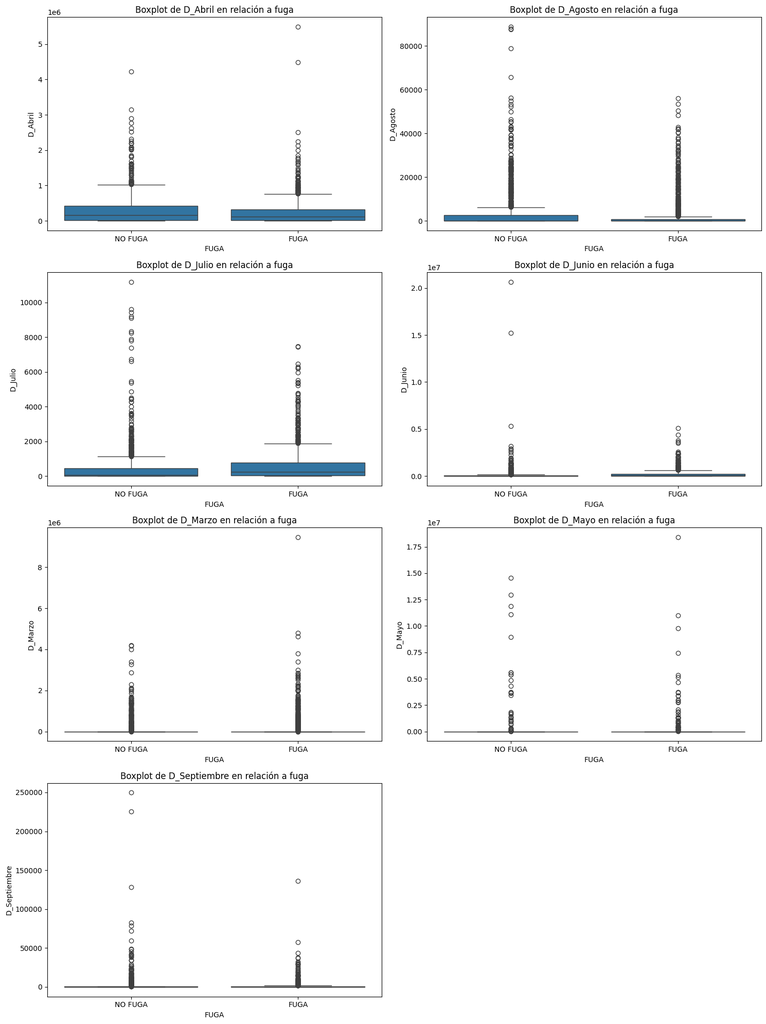

```python
columns_to_exclude = ['ID', 'RENTA', 'EDAD', 'MONTO', 'M_MOROSO', 'COD_COM', 'COD_OFI']
numeric_columns = data.select_dtypes(include=['float', 'int64']).columns.difference(columns_to_exclude)

# Definir el número de filas y columnas para los subplots
n_cols = 2  # Número de columnas
n_rows = len(numeric_columns) // n_cols + (len(numeric_columns) % n_cols > 0)  # Calcular las filas necesarias

# Crear subplots
fig, axes = plt.subplots(n_rows, n_cols, figsize=(15, n_rows * 5))  # Ajustar el tamaño de la figura
axes = axes.flatten()  # Aplanar la matriz de ejes

# Crear un boxplot para cada variable numérica
for i, column in enumerate(numeric_columns):
    sns.boxplot(y=data[column], x=data['FUGA'], ax=axes[i])  # Solo graficar la variable en el eje y
    axes[i].set_title(f'Boxplot de {column} en relación a fuga')  # Agregar título a cada gráfico

# Eliminar los ejes sobrantes si los hay
for i in range(len(numeric_columns), len(axes)):
    fig.delaxes(axes[i])

plt.tight_layout()  # Ajustar el espaciado
plt.show()
```

En los 7 boxplots de Deuda Mensual vs Fuga, podemos observar una cantidad considerable de valores por encima del percentil 75. Sin embargo, para considerarlos como outliers, habría que analizar detenidamente cada atributo:

- 'D_Marzo': En este mes, se observan outliers de deuda superior a 8 millones, el cual se escapa de los demás valores por sobre el percentil 75 presente en la categoría 'SI'.
- 'D_Abril': Este mes hay 3 valores por sobre los 4 millones en ambas categorías que se alejan de los demás valores atípicos.
- 'D_Mayo': Existen un valor atípico por encima de los 17 millones en la categoría 'SI'.
- 'D_Junio': Existen 2 valores atípicos sobre los 15 millones.
- 'D_Julio': Existe un valor atípico de 10 mil en la etiqueta 'NO'
- 'D_Agosto': Existen unos valores atípicos superiores a 60 mil en la categoría 'NO'
- 'D_Septiembre': Hay presencia de valores atípicos por sobre los 100 mil en ambas categorías

##### 1.4.1.2 Renta vs Fuga

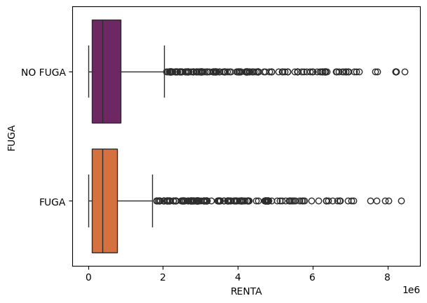

```python
# Index(['ID', 'GENERO', 'RENTA', 'EDAD', 'NIV_EDUC', 'E_CIVIL',
  # 'COD_OFI', 'COD_COM', 'CIUDAD', 'D_Marzo', 'D_Abril', 'D_Mayo',
  # 'D_Junio','D_Julio', 'D_Agosto', 'D_Septiembre', 'M_MOROSO', 'MONTO', 'SEGURO','FUGA']

# Boxplot columna 'RENTA' respecto a 'FUGA'

sns.boxplot(x='RENTA',y='FUGA',hue='FUGA',data=data, palette='inferno')
```

Si bien en este bloxplot podemos observar que existen valores por encima del percentil 75, estos valores parecen ser válidamente recogidos, ya que es probable que existan personas con rentas superiores a 2 millones aproximandamente, como se observa en ambas etiquetas de fuga.

##### 1.4.1.3 Edad vs Fuga

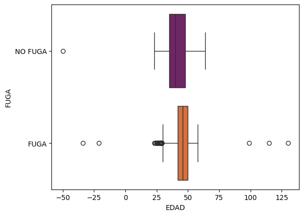

```python
# Index(['ID', 'GENERO', 'RENTA', 'EDAD', 'NIV_EDUC', 'E_CIVIL',
  # 'COD_OFI', 'COD_COM', 'CIUDAD', 'D_Marzo', 'D_Abril', 'D_Mayo',
  # 'D_Junio','D_Julio', 'D_Agosto', 'D_Septiembre', 'M_MOROSO', 'MONTO', 'SEGURO','FUGA']

# Boxplot columna 'EDAD' respecto a 'FUGA'

sns.boxplot(x='EDAD',y='FUGA',hue='FUGA',data=data, palette='inferno')
```

```python
# Edades mayores iguale a 100 años

data[data['EDAD'] >= 90]
```

|  | ID | GENERO | RENTA | EDAD | NIV_EDUC | E_CIVIL | COD_OFI | COD_COM | CIUDAD | D_Marzo | D_Abril | D_Mayo | D_Junio | D_Julio | D_Agosto | D_Septiembre | M_MOROSO | MONTO | SEGURO | FUGA |
| --- | --- | --- | --- | --- | --- | --- | --- | --- | --- | --- | --- | --- | --- | --- | --- | --- | --- | --- | --- | --- |
| 583 | 584 | M | 3976014 | 115.0 | UNV | CAS | 55 | 90.0 | SANTIAGO | 0 | 0 | 0 | 0 | 148 | 0 | 0 | 1 | 1800000 | NO | FUGA |
| 1480 | 1481 | M | 130582 | 130.0 | UNV | CAS | 31 | 119.0 | SANTIAGO | 0 | 1239039 | 0 | 952369 | 140 | 0 | 1075 | 2 | 1100000 | NO | FUGA |
| 1797 | 1798 | M | 647536 | 99.0 | MED | CAS | 122 | 97.0 | SANTIAGO | 0 | 169828 | 0 | 274195 | 450 | 4286 | 206 | 2 | 1800000 | NO | FUGA |

En el boxplot de edad vs fuga, podemos observar ciertas anomalías, por ejemplo, que existen edades menores a cero y edades superiores a 90 años. Para ambos casos, se considerarán outliers los siguientes valores:

Edades Menores a 0 Edades superiores a 90 años

##### 1.4.1.4 Monto vs Fuga

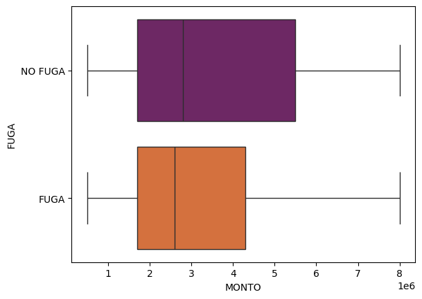

```python
# Index(['ID', 'GENERO', 'RENTA', 'EDAD', 'NIV_EDUC', 'E_CIVIL',
  # 'COD_OFI', 'COD_COM', 'CIUDAD', 'D_Marzo', 'D_Abril', 'D_Mayo',
  # 'D_Junio','D_Julio', 'D_Agosto', 'D_Septiembre', 'M_MOROSO', 'MONTO', 'SEGURO','FUGA']

# Boxplot columna 'MONTO' respecto a 'FUGA'

sns.boxplot(x='MONTO',y='FUGA',hue='FUGA',data=data, palette='inferno')
```

A partir del boxplot Monto vs Fuga, podemos observar que no hay presencia de outliers.

##### 1.4.1.5 M_MOROSO vs Fuga

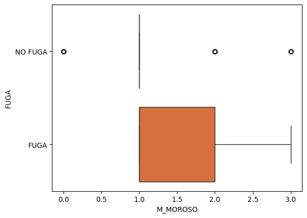

```python
# Index(['ID', 'GENERO', 'RENTA', 'EDAD', 'NIV_EDUC', 'E_CIVIL',
  # 'COD_OFI', 'COD_COM', 'CIUDAD', 'D_Marzo', 'D_Abril', 'D_Mayo',
  # 'D_Junio','D_Julio', 'D_Agosto', 'D_Septiembre', 'M_MOROSO', 'MONTO', 'SEGURO','FUGA']

# Boxplot columna 'M_MOROSO' respecto a 'FUGA'

sns.boxplot(x='M_MOROSO',y='FUGA',hue='FUGA',data=data, palette='inferno')
```

A partir del boxplot de la cantidad de veces que un cliente ha estado en mora, si bien hay presencia de outliers, la cantidad indica comportamiento del cliente, por ende, estos valores fuera de rango no se considerarán outliers.

##### 1.4.5 Histplot para columnas numéricas

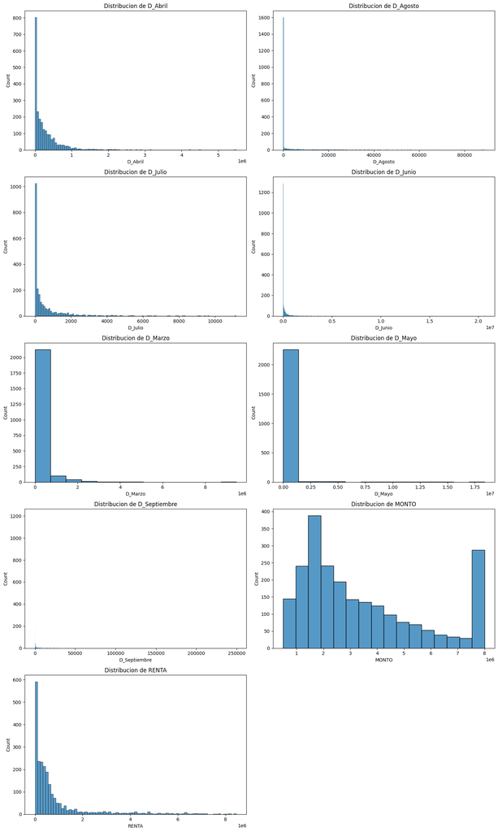

```python
columns_to_exclude = ['ID', 'M_MOROSO','COD_COM','COD_OFI','EDAD']
numeric_columns = data.select_dtypes(include=['float', 'int64']).columns.difference(columns_to_exclude)

# Definir el número de filas y columnas para los subplots
n_cols = 2  # Número de columnas
n_rows = len(numeric_columns) // n_cols + (len(numeric_columns) % n_cols > 0)  # Calcular las filas necesarias

# Crear subplots
fig, axes = plt.subplots(n_rows, n_cols, figsize=(15, n_rows * 5))  # Ajustar el tamaño de la figura
axes = axes.flatten()  # Aplanar la matriz de ejes

# Crear un boxplot para cada variable numérica
for i, column in enumerate(numeric_columns):
    sns.histplot(x=data[column], ax=axes[i])  # Solo graficar la variable en el eje y
    axes[i].set_title(f'Distribucion de {column}')  # Agregar título a cada gráfico

# Eliminar los ejes sobrantes si los hay
for i in range(len(numeric_columns), len(axes)):
    fig.delaxes(axes[i])

plt.tight_layout()  # Ajustar el espaciado
plt.show()
```

Para mejorar la interpretabilidad de estos datos y evitar la presencia de valores atípicos que podrían distorsionar el análisis, se realizará un tratamiento de normalización. Este proceso ayudará a reducir las diferencias extremas y a obtener una distribución más equilibrada, lo que facilitará la comparación entre variables y mejorará la precisión de futuros modelos analíticos.

## 2 **Transformación y Creación de indicadores**

### 2.1 Aplicación logaritmo

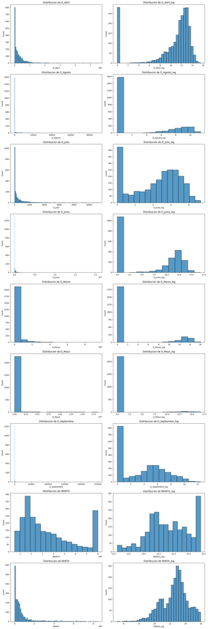

```python
columns_to_exclude = ['ID', 'M_MOROSO','COD_COM','COD_OFI','EDAD']
numeric_columns = data.select_dtypes(include=['float', 'int64']).columns.difference(columns_to_exclude)

for column in numeric_columns:
    # Agrega 1 a los valores para evitar el logaritmo de cero
    data[column+'_log'] = np.log1p(data[column])

numeric_columns = data.select_dtypes(include=['float', 'int64']).columns.difference(columns_to_exclude)
n_cols = 2  # Número de columnas
n_rows = len(numeric_columns) // n_cols + (len(numeric_columns) % n_cols > 0)  # Calcular las filas necesarias

# Crear subplots
fig, axes = plt.subplots(n_rows, n_cols, figsize=(15, n_rows * 5))  # Ajustar el tamaño de la figura
axes = axes.flatten()  # Aplanar la matriz de ejes

# Crear un boxplot para cada variable numérica
for i, column in enumerate(numeric_columns):
    sns.histplot(x=data[column], ax=axes[i])  # Solo graficar la variable en el eje y
    axes[i].set_title(f'Distribucion de {column}')  # Agregar título a cada gráfico

# Eliminar los ejes sobrantes si los hay
for i in range(len(numeric_columns), len(axes)):
    fig.delaxes(axes[i])

plt.tight_layout()  # Ajustar el espaciado
plt.show()
```

Gracias a la transformacion logaritmicas podemos ver (paneles de la derecha), la dispersión de los valores está más equilibrada y se observa una distribución menos sesgada, especialmente en las variables de deuda mensual (D_mes), MONTO, y RENTA. La transformación logarítmica ayuda a reducir la asimetría y hace que los datos se acerquen a una distribución más normal, lo que es beneficioso para muchos modelos de análisis y facilita la interpretación de las variaciones entre valores.

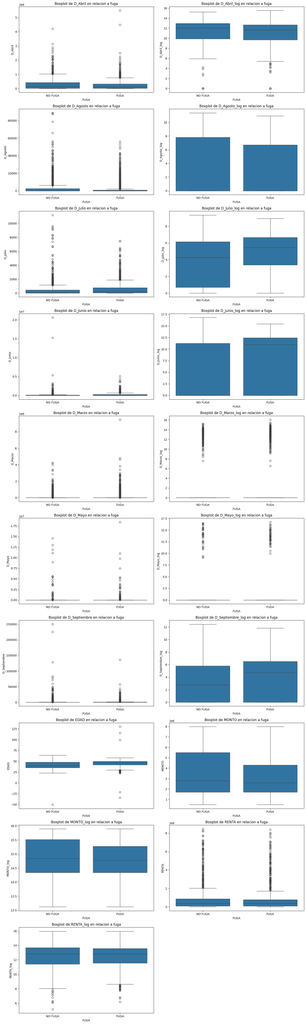

```python
columns_to_exclude = ['ID', 'M_MOROSO','COD_COM','COD_OFI']
numeric_columns = data.select_dtypes(include=['float', 'int64']).columns.difference(columns_to_exclude)

# Definir el número de filas y columnas para los subplots
n_cols = 2  # Número de columnas
n_rows = len(numeric_columns) // n_cols + (len(numeric_columns) % n_cols > 0)  # Calcular las filas necesarias

# Crear subplots
fig, axes = plt.subplots(n_rows, n_cols, figsize=(15, n_rows * 5))  # Ajustar el tamaño de la figura
axes = axes.flatten()  # Aplanar la matriz de ejes

# Crear un boxplot para cada variable numérica
for i, column in enumerate(numeric_columns):
    sns.boxplot(y=data[column], x=data['FUGA'], ax=axes[i])  # Solo graficar la variable en el eje y
    axes[i].set_title(f'Boxplot de {column} en relacion a fuga')  # Agregar título a cada gráfico

# Eliminar los ejes sobrantes si los hay
for i in range(len(numeric_columns), len(axes)):
    fig.delaxes(axes[i])

plt.tight_layout()  # Ajustar el espaciado
plt.show()
```

## 3 **Imputación y Eliminación de valores perdidos/inconsistentes**

```python
percentil_inferior = 0.05
percentil_superior = 0.95

# Calcular los percentiles
percentil_inf = data['EDAD'].quantile(percentil_inferior)
percentil_sup = data['EDAD'].quantile(percentil_superior)

# Filtrar los datos para eliminar los outliers
data = data[(data['EDAD'] >= percentil_inf) & (data['EDAD'] <= percentil_sup)]

#eliminar nan
data = data.dropna()
```

Este código implementa una técnica de limpieza de outliers que elimina valores atípicos de la columna EDAD basados en los percentiles 5% y 95%

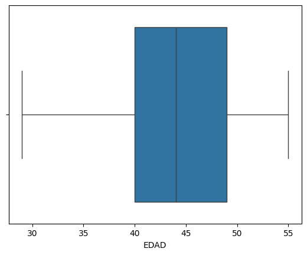

```python
sns.boxplot(x=data['EDAD'])
```

## **4 Selección de Atributos**

### 4.1 Conversion variable objetivo

con el fin de poder medir la correlacion entre variables numericas con la objetivo se hace la conversion de esta a binario

```python
data['FUGA'] = data['FUGA'].map({'NO FUGA':0, 'FUGA':1})
data['FUGA'].unique()
```

```
array([0, 1])
```

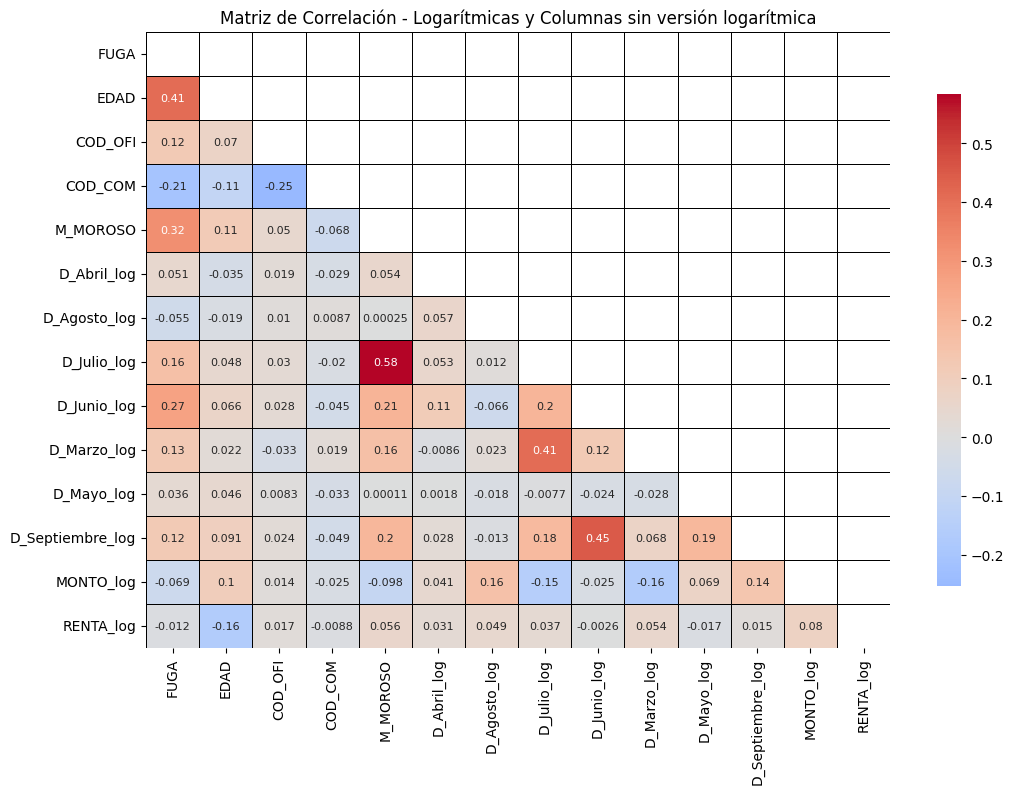

```python
# Seleccionamos las columnas que contienen '_log' en el nombre
log_columns = data.filter(regex='_log').columns

# Obtenemos las columnas "base" eliminando '_log' de los nombres de las columnas logarítmicas
base_columns = [col.replace('_log', '') for col in log_columns]

# Filtramos todas las columnas que no tienen versión logarítmica o que son logarítmicas,
# excluyendo columnas específicas y columnas no numéricas
selected_columns = data.columns[
    (data.columns.isin(log_columns) | ~data.columns.isin(base_columns)) &
    ~data.columns.isin(['ID', 'GENERO', 'NIV_EDUC', 'E_CIVIL', 'SEGURO', 'CIUDAD'])
]

# Seleccionamos solo las columnas numéricas
numeric_data = data[selected_columns].select_dtypes(include=['float', 'int'])

# Reorganizamos las columnas para que 'FUGA' sea la primera
if 'FUGA' in numeric_data.columns:
    ordered_columns = ['FUGA'] + [col for col in numeric_data.columns if col != 'FUGA']
    numeric_data = numeric_data[ordered_columns]

# Calculamos la matriz de correlación solo con las columnas seleccionadas y numéricas
corr_matrix = numeric_data.corr()

# Creamos una máscara para resaltar solo la fila y columna de FUGA
highlight_mask = np.zeros_like(corr_matrix, dtype=bool)
if 'FUGA' in corr_matrix.columns:
    target_idx = corr_matrix.columns.get_loc('FUGA')
    highlight_mask[:, target_idx] = True
    highlight_mask[target_idx, :] = True

# Generamos la máscara para graficar solo la mitad de la matriz
mask = np.triu(np.ones_like(corr_matrix, dtype=bool))

# Creamos el mapa de calor, aplicando el highlight_mask para resaltar FUGA
plt.figure(figsize=(12, 8))
sns.heatmap(corr_matrix, mask=mask, annot=True, cmap="coolwarm", center=0,
            cbar_kws={"shrink": 0.8}, linewidths=0.5, linecolor='black',
            annot_kws={"size": 8})
plt.title("Matriz de Correlación - Logarítmicas y Columnas sin versión logarítmica")
plt.show()
```

La matriz de correlación muestra que la variable "FUGA" no tiene una fuerte correlación con ninguna de las otras variables. "EDAD" y "M_MOROSO" son las que tienen una correlación más fuerte con "FUGA", pero aún así no es una correlación muy alta. Las demás variables tienen una correlación débil con "FUGA".

### 4.2 Test Chi-square

```python
import pandas as pd
from scipy.stats import chi2_contingency

str_columns = data.select_dtypes(include=['object'])
alpha = 0.05

for columna in str_columns.columns:
    c_table = pd.crosstab(data['FUGA'], data[columna])
    stat, p_val, dof, expected = chi2_contingency(c_table)

    print(f"Análisis de la columna: {columna}")
    print(f"p-value = {round(p_val,4)} | estadístico: {round(stat,3)}")
    if p_val <= alpha:
        print('Las variables son dependientes (Rechaza Hipótesis Nula)  | Existe relación entre las variables')
    else:
        print('Las variables son independientes (Acepta Hipótesis Nula) | No existe relación entre las variables')
    print("-------------------------------------------")
```

```
Análisis de la columna: GENERO
p-value = 0.0 | estadístico: 470.954
Las variables son dependientes (Rechaza Hipótesis Nula)  | Existe relación entre las variables
-------------------------------------------
Análisis de la columna: NIV_EDUC
p-value = 0.0 | estadístico: 548.525
Las variables son dependientes (Rechaza Hipótesis Nula)  | Existe relación entre las variables
-------------------------------------------
Análisis de la columna: E_CIVIL
p-value = 0.0 | estadístico: 170.143
Las variables son dependientes (Rechaza Hipótesis Nula)  | Existe relación entre las variables
-------------------------------------------
Análisis de la columna: CIUDAD
p-value = 0.0 | estadístico: 720.033
Las variables son dependientes (Rechaza Hipótesis Nula)  | Existe relación entre las variables
-------------------------------------------
Análisis de la columna: SEGURO
p-value = 0.0 | estadístico: 16.457
Las variables son dependientes (Rechaza Hipótesis Nula)  | Existe relación entre las variables
-------------------------------------------
```

Como se rechaza la hipótesis nula, las columnas categorias son relevantes al momento de predecir si un cliente se fugara.

```python
def cramers_v(contingency_table):
    chi2, _, _, _ = chi2_contingency(contingency_table)
    n = contingency_table.sum().sum()
    k = min(contingency_table.shape) - 1
    return np.sqrt(chi2 / (n * k))

results = {}

for col in ['GENERO', 'NIV_EDUC', 'E_CIVIL', 'CIUDAD', 'SEGURO']:
    contingency_table = pd.crosstab(data[col], data['FUGA'])
    results[col] = cramers_v(contingency_table)

# Ordenar y mostrar los resultados
sorted_results = sorted(results.items(), key=lambda x: x[1], reverse=True)
for col, v in sorted_results:
    print(f"{col}: Cramer’s V = {v:.4f}")
```

```
CIUDAD: Cramer’s V = 0.5898
NIV_EDUC: Cramer’s V = 0.5148
GENERO: Cramer’s V = 0.4770
E_CIVIL: Cramer’s V = 0.2867
SEGURO: Cramer’s V = 0.0892
```

A continuación, se calculó el coeficiente de Cramér's V para evaluar la fuerza de asociación entre la variable objetivo (FUGA) y varias variables categóricas. Los resultados muestran los valores de Cramér's V para cada variable:

[output not shown]

Siguiendo el criterio de seleccionar variables con un Cramér’s V superior a 0.5, se eligen las variables CIUDAD y NIV_EDUC para el entrenamiento del modelo. Estas variables presentan una asociación más fuerte con la variable objetivo y, por lo tanto, podrían aportar mayor información para la predicción de la fuga.

### 4.3 Test Kolmogorov-Smirnov

```python
def ecdf(data):
    # Computa la distribución empirica acumulada (ECDF por sus siglas en ingles)
    x = np.sort(data)
    n = x.size
    y = np.arange(1, n+1) / n
    return x,y

def plot_kolmogorov(sample1, sample2,variable_name='',alpha=0.05):
  import matplotlib.pyplot as plt
  from scipy import stats
  # obtenemos la ECDF para cada muestra y las ordenamos
  x1,y1 = ecdf(sample1)
  x2,y2 = ecdf(sample2)
  # plot
  plt.figure(figsize=(6, 5))
  sns.lineplot(x=x1, y=y1, color='red')
  sns.lineplot(x=x2, y=y2, color='blue')
  # test
  stat, p_val = stats.ks_2samp(sample1, sample2)
  # interpretamos el p-value
  print(f"p-value: {round(p_val,4)} | alpha: {alpha}")
  if p_val < alpha:
      print('Las distribuciones son independientes (Rechaza Hipótesis Nula) | Existe relación entre las varibles')
  else:
      print('Las distribuciones son dependientes (Acepta Hipótesis Nula) | No existe relación entre las varibles')
  plt.ylabel("Cumulative Distribution Function")
  plt.xlabel(variable_name)
  plt.show()
```

```
Analisis columna D_Abril
p-value: 0.001 | alpha: 0.05
Las distribuciones son independientes (Rechaza Hipótesis Nula) | Existe relación entre las varibles
```

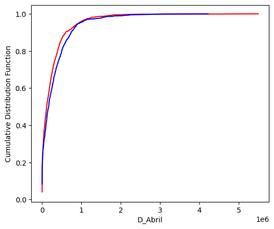

```
Analisis columna D_Abril_log
p-value: 0.001 | alpha: 0.05
Las distribuciones son independientes (Rechaza Hipótesis Nula) | Existe relación entre las varibles
```

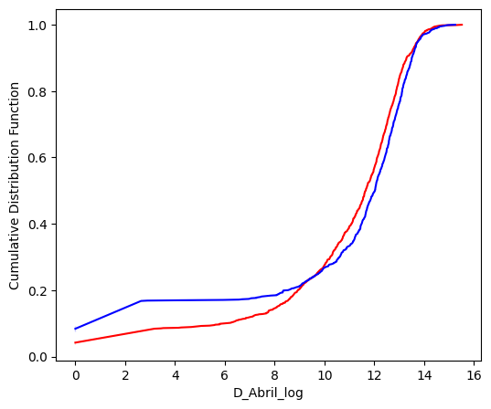

```
Analisis columna D_Agosto
p-value: 0.0285 | alpha: 0.05
Las distribuciones son independientes (Rechaza Hipótesis Nula) | Existe relación entre las varibles
```

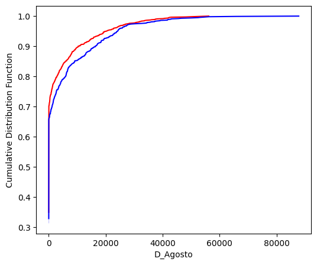

```
Analisis columna D_Agosto_log
p-value: 0.0285 | alpha: 0.05
Las distribuciones son independientes (Rechaza Hipótesis Nula) | Existe relación entre las varibles
```

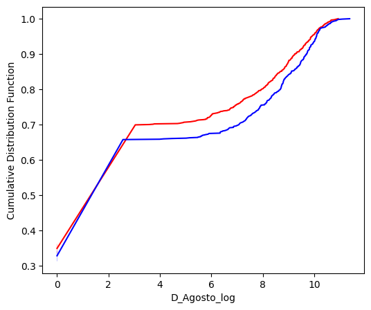

```
Analisis columna D_Julio
p-value: 0.0 | alpha: 0.05
Las distribuciones son independientes (Rechaza Hipótesis Nula) | Existe relación entre las varibles
```

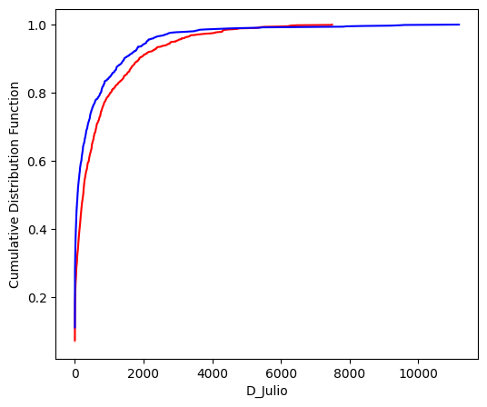

```
Analisis columna D_Julio_log
p-value: 0.0 | alpha: 0.05
Las distribuciones son independientes (Rechaza Hipótesis Nula) | Existe relación entre las varibles
```

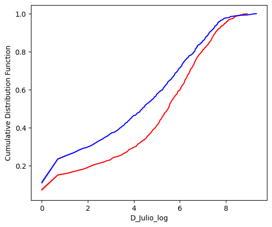

```
Analisis columna D_Junio
p-value: 0.0 | alpha: 0.05
Las distribuciones son independientes (Rechaza Hipótesis Nula) | Existe relación entre las varibles
```

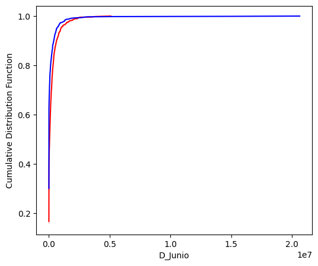

```
Analisis columna D_Junio_log
p-value: 0.0 | alpha: 0.05
Las distribuciones son independientes (Rechaza Hipótesis Nula) | Existe relación entre las varibles
```

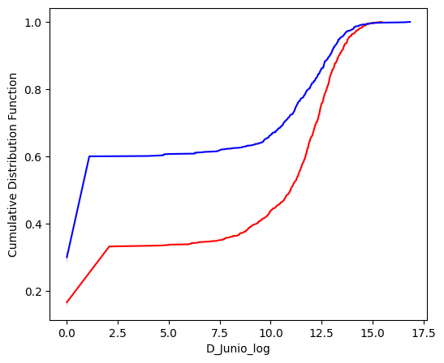

```
Analisis columna D_Marzo
p-value: 0.0 | alpha: 0.05
Las distribuciones son independientes (Rechaza Hipótesis Nula) | Existe relación entre las varibles
```

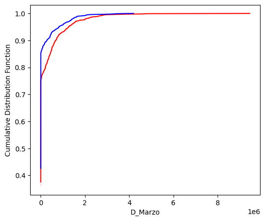

```
Analisis columna D_Marzo_log
p-value: 0.0 | alpha: 0.05
Las distribuciones son independientes (Rechaza Hipótesis Nula) | Existe relación entre las varibles
```

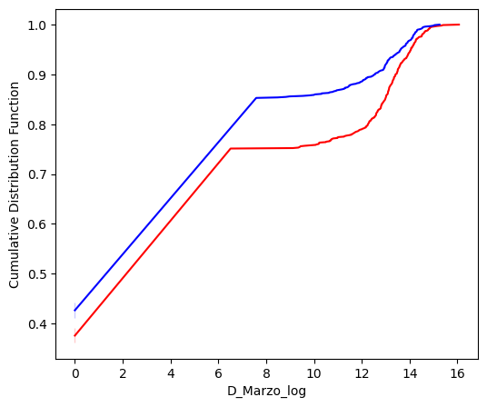

```
Analisis columna D_Mayo
p-value: 0.9981 | alpha: 0.05
Las distribuciones son dependientes (Acepta Hipótesis Nula) | No existe relación entre las varibles
```

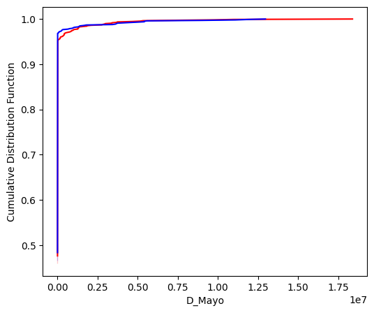

```
Analisis columna D_Mayo_log
p-value: 0.9981 | alpha: 0.05
Las distribuciones son dependientes (Acepta Hipótesis Nula) | No existe relación entre las varibles
```

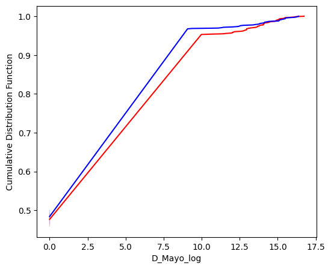

```
Analisis columna D_Septiembre
p-value: 0.0 | alpha: 0.05
Las distribuciones son independientes (Rechaza Hipótesis Nula) | Existe relación entre las varibles
```

[7 more figures not shown]

```python
for variable in numeric_columns:
  print(f'Analisis columna {variable}')
  plot_kolmogorov(data[data['FUGA']==1][variable].values, data[data['FUGA']==0][variable].values, variable)
```

### 4.4 Creacion de kpi

```python
# Creamos indicadores, nuevas variables en el dataset limpio que nos pueden ayudar a entener tendencias

# 1. Promedio de deudas mensuales
data['Promedio_Deuda'] = data[['D_Marzo', 'D_Abril', 'D_Mayo', 'D_Junio', 'D_Julio', 'D_Agosto', 'D_Septiembre']].mean(axis=1)

# 2. Ratio de morosidad (número de veces en mora / número de meses con deuda)
months_with_debt = (data[['D_Marzo', 'D_Abril', 'D_Mayo', 'D_Junio', 'D_Julio', 'D_Agosto', 'D_Septiembre']] > 0).sum(axis=1)
data['Ratio_Morosidad'] = data['M_MOROSO'] / months_with_debt.replace(0, 1)

# 3. Renta por Edad
data['Renta_Edad'] = data['RENTA'] / data['EDAD'].replace(0, 1)

# 4. Endeudamiento Total (Suma de las deudas mensuales)
data['Endeudamiento_Total'] = data[['D_Marzo', 'D_Abril', 'D_Mayo', 'D_Junio', 'D_Julio', 'D_Agosto', 'D_Septiembre']].sum(axis=1)

# 5. Deuda respecto a Renta
data['Deuda_Renta'] = data['Endeudamiento_Total'] / data['RENTA'].replace(0, 1)

# 6. Variabilidad de deudas (Desviación estándar de las deudas mensuales)
data['Variabilidad_Deuda'] = data[['D_Marzo', 'D_Abril', 'D_Mayo', 'D_Junio', 'D_Julio', 'D_Agosto', 'D_Septiembre']].std(axis=1)

# Mostrar las primeras filas con las nuevas variables
data[['Promedio_Deuda', 'Ratio_Morosidad', 'Renta_Edad', 'Endeudamiento_Total', 'Deuda_Renta', 'Variabilidad_Deuda']].head()
```

|  | Promedio_Deuda | Ratio_Morosidad | Renta_Edad | Endeudamiento_Total | Deuda_Renta | Variabilidad_Deuda |
| --- | --- | --- | --- | --- | --- | --- |
| 0 | 69123.571429 | 0.40 | 19140.410256 | 483865 | 0.648199 | 161643.656582 |
| 1 | 6.857143 | 1.00 | 242.877551 | 48 | 0.004033 | 18.142295 |
| 2 | 90558.000000 | 0.25 | 42344.128205 | 633906 | 0.383855 | 226688.202931 |
| 3 | 29188.857143 | 0.25 | 17749.138889 | 204322 | 0.319768 | 74902.785686 |
| 4 | 12332.285714 | 0.25 | 19548.022727 | 86326 | 0.100366 | 27532.223198 |

### 4.5 Resumen selección de atributos

En síntesis, en este dataset realizamos lo siguiente:

- Se realizó un tratamiento a las columnas por las presencia de posibles outliers, por la naturaleza de la data se puede entender de que no son outliers
- Gracias a la matriz de correlacion con la variable objetivo se dejan las columnas 'EDAD','M_MOROSO','D_Julio_log','D_Junio_log' por tener una correlacion mas fuerte con la variable objetivo FUGA
- Por Cramer's se descartan las columnas con un coeficiente menor a 0.5 que serian las columnas GENERO, E_CIVIL,SEGURO
- Por otro lado, se descarta la columna COD_COM y RENTA por no ser relevante por test kolmogorov-smirnov.

Por tanto, nuestro dataset final donde imputamos los valores perdidos, eliminamos outliers quedará de la siguiente forma:

```python
df_encoded = pd.get_dummies(data, columns=['NIV_EDUC','CIUDAD'], drop_first=True)
```

```python
# dataset final

categorical_columns  = df_encoded.select_dtypes(include=['bool']).columns.tolist()
selected_columns = categorical_columns + ['EDAD','M_MOROSO','D_Julio_log','D_Junio_log','FUGA','Promedio_Deuda', 'Ratio_Morosidad', 'Renta_Edad', 'Endeudamiento_Total', 'Deuda_Renta', 'Variabilidad_Deuda']

df = df_encoded[selected_columns]
```

## 5 Entrenamiento del Modelo

### 5.1 Random Forest

```
Importancia de características:
                 Feature  Importance
72                 EDAD    0.188493
3          NIV_EDUC_UNV    0.103499
77      Ratio_Morosidad    0.070446
2          NIV_EDUC_TEC    0.067406
74          D_Julio_log    0.055728
..                  ...         ...
53  CIUDAD_SAN CLEMENTE    0.000000
33     CIUDAD_LOS LAGOS    0.000000
34     CIUDAD_LOS VILOS    0.000000
4          CIUDAD_ANGOL    0.000000
35       CIUDAD_MACHALI    0.000000

[82 rows x 2 columns]
```

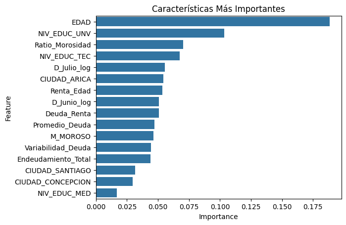

```python
# Supongamos que tienes un DataFrame `df` y que 'FUGA' es la variable objetivo
X = df.drop(columns='FUGA')
y = df['FUGA']

# División de datos en entrenamiento y prueba
X_train, X_test, y_train, y_test = train_test_split(X, y, test_size=0.3, random_state=42)

# Entrenamiento del modelo Random Forest
random_forest = RandomForestClassifier(random_state=42)
random_forest.fit(X_train, y_train)

# Crear el DataFrame con la importancia de características
importances = pd.DataFrame({
    'Feature': X.columns,
    'Importance': random_forest.feature_importances_
})
importances = importances.sort_values(by='Importance', ascending=False)

# Imprimir la importancia de características
print("Importancia de características:\n", importances)

# Visualización de la importancia de características
threshold = 0.01
important_features = importances[importances['Importance'] > threshold]

# Visualizar solo las características importantes
sns.barplot(x='Importance', y='Feature', data=important_features)
plt.title("Características Más Importantes")
plt.show()
```

```python
X_train, X_test, y_train, y_test = train_test_split(df.drop('FUGA', axis=1), df['FUGA'], test_size=0.2, random_state=42)
```

### 5.2 Métricas

```python
def metricas(y_test, y_pred, y_proba, modelo):
    return {
        'Modelo': modelo,
        'Accuracy': accuracy_score(y_test, y_pred),
        'Precision': precision_score(y_test, y_pred),
        'Recall': recall_score(y_test, y_pred),
        'F1 Score': f1_score(y_test, y_pred),
        'ROC-AUC Score': roc_auc_score(y_test, y_proba)
    }
```

```python
log_reg = LogisticRegression(max_iter=1000)
log_reg.fit(X_train, y_train)

y_pred_log_reg = log_reg.predict(X_test)
y_proba_log_reg = log_reg.predict_proba(X_test)[:, 1]

random_forest = RandomForestClassifier(
    n_estimators=40,      # Menos árboles para evitar sobreajuste
    random_state=42,
    max_depth=10,         # Limitar la profundidad de los árboles
    min_samples_split=15, # Aumentar el mínimo de muestras para dividir un nodo
    min_samples_leaf=5,   # Aumentar el mínimo de muestras en una hoja
    class_weight='balanced'  # Ajustar si hay clases desbalanceadas
)
random_forest.fit(X_train, y_train)
y_pred_rf = random_forest.predict(X_test)

y_proba_rf = random_forest.predict_proba(X_test)[:, 1]

svm = SVC(probability=True, random_state=42)
svm.fit(X_train, y_train)

y_pred_svm = svm.predict(X_test)
y_proba_svm = svm.predict_proba(X_test)[:, 1]
```

```python
log_reg = LogisticRegression(max_iter=1000)
log_reg.fit(X_train, y_train)

y_pred_log_reg = log_reg.predict(X_test)
y_proba_log_reg = log_reg.predict_proba(X_test)[:, 1]

random_forest = RandomForestClassifier(
    n_estimators=40,      # Menos árboles para evitar sobreajuste
    random_state=42,
    max_depth=10,         # Limitar la profundidad de los árboles
    min_samples_split=15, # Aumentar el mínimo de muestras para dividir un nodo
    min_samples_leaf=5,   # Aumentar el mínimo de muestras en una hoja
    class_weight='balanced'  # Ajustar si hay clases desbalanceadas
)
random_forest.fit(X_train, y_train)
y_pred_rf = random_forest.predict(X_test)

y_proba_rf = random_forest.predict_proba(X_test)[:, 1]

svm = SVC(probability=True, random_state=42)
svm.fit(X_train, y_train)

y_pred_svm = svm.predict(X_test)
y_proba_svm = svm.predict_proba(X_test)[:, 1]
```

```python
resultados = []

resultados.append(metricas(y_test, y_pred_log_reg, y_proba_log_reg, 'Regresión Logística'))
resultados.append(metricas(y_test, y_pred_rf, y_proba_rf, 'Random Forest'))
resultados.append(metricas(y_test, y_pred_svm, y_proba_svm, 'SVM'))

resultados_df = pd.DataFrame(resultados)
resultados_df
```

|  | Modelo | Accuracy | Precision | Recall | F1 Score | ROC-AUC Score |
| --- | --- | --- | --- | --- | --- | --- |
| 0 | Regresión Logística | 0.756039 | 0.766520 | 0.783784 | 0.775056 | 0.839058 |
| 1 | Random Forest | 0.886473 | 0.899543 | 0.887387 | 0.893424 | 0.948163 |
| 2 | SVM | 0.553140 | 0.573705 | 0.648649 | 0.608879 | 0.574700 |

despues de realizar los entrenamientos basicos se puede ver que estos modelos se encuentran overfitting, por lo que hare un tratamiento para poder encontrar un mejor resultado

```python
from sklearn.model_selection import train_test_split, RandomizedSearchCV
```

### 5.3 Busqueda hiperparametros

```python
param_grid_log_reg = {
    'penalty': ['l2'],
    'C': [0.1, 1],
    'solver': ['liblinear'],
}

halving_grid_search_log_reg = HalvingRandomSearchCV(
    LogisticRegression(max_iter=1000),
    param_grid_log_reg,
    factor=2,
    cv=3,
    scoring='recall',
    n_jobs=-1,
    random_state=42
)
halving_grid_search_log_reg.fit(X_sample, y_sample)

print("Best parameters for Logistic Regression: ", halving_grid_search_log_reg.best_params_)
```

```
Best parameters for Logistic Regression:  {'solver': 'liblinear', 'penalty': 'l2', 'C': 1}
```

```python
param_grid_rf = {
    'n_estimators': [50],
    'max_depth': [10],
    'min_samples_split': [2],
    'min_samples_leaf': [1]
}

# HalvingRandomSearchCV para Random Forest
halving_grid_search_rf = HalvingRandomSearchCV(
    RandomForestClassifier(random_state=42),
    param_grid_rf,
    factor=2,
    cv=3,
    scoring='recall',
    n_jobs=-1,
    random_state=42
)
halving_grid_search_rf.fit(X_sample, y_sample)
print("Best parameters for Random Forest: ", halving_grid_search_rf.best_params_)
```

```
Best parameters for Random Forest:  {'n_estimators': 50, 'min_samples_split': 2, 'min_samples_leaf': 1, 'max_depth': 10}
```

```python
from sklearn.experimental import enable_halving_search_cv  # Habilitar la funcionalidad experimental
from sklearn.model_selection import HalvingRandomSearchCV  # Ahora puedes usar HalvingRandomSearchCV

X_sample, _, y_sample, _ = train_test_split(X_train, y_train, test_size=0.9, random_state=42)

# Definir los parámetros de búsqueda
param_grid_svm = {
    'C': [0.1, 1, 10],
    'kernel': ['linear', 'rbf'],
    'gamma': ['scale', 'auto']
}

# Configurar HalvingRandomSearchCV sin min_resources='exhaust'
halving_grid_search_svm = HalvingRandomSearchCV(
    SVC(probability=True, random_state=42),
    param_grid_svm,
    factor=2,
    cv=3,
    scoring='recall',
    n_jobs=-1,
    random_state=42,
    max_resources='auto'  # Dejamos que la cantidad de recursos se maneje automáticamente
)

# Ajustar el modelo
halving_grid_search_svm.fit(X_sample, y_sample)

# Imprimir los mejores parámetros encontrados
print("Best parameters for SVM: ", halving_grid_search_svm.best_params_)
```

[output not shown]

### 5.4 Modelo entrenado con valores arrojados por busqueda hiperparametros

```python
log_reg = LogisticRegression(C=1, penalty='l2', solver='liblinear')
log_reg.fit(X_train, y_train)

y_pred_log_reg = log_reg.predict(X_test)
y_proba_log_reg = log_reg.predict_proba(X_test)[:, 1]

random_forest = RandomForestClassifier(max_depth=10,min_samples_leaf=1,min_samples_split=2, n_estimators=50)
random_forest.fit(X_train, y_train)

y_pred_rf = random_forest.predict(X_test)
y_proba_rf = random_forest.predict_proba(X_test)[:, 1]

svm = SVC(probability=True,C=1, gamma='scale', kernel='rbf')
svm.fit(X_train, y_train)

y_pred_svm = svm.predict(X_test)
y_proba_svm = svm.predict_proba(X_test)[:, 1]

resultados = []

resultados.append(metricas(y_test, y_pred_log_reg, y_proba_log_reg, 'Regresión Logística'))
resultados.append(metricas(y_test, y_pred_rf, y_proba_rf, 'Random Forest'))
resultados.append(metricas(y_test, y_pred_svm, y_proba_svm, 'SVM'))

resultados_df = pd.DataFrame(resultados)
resultados_df
```

|  | Modelo | Accuracy | Precision | Recall | F1 Score | ROC-AUC Score |
| --- | --- | --- | --- | --- | --- | --- |
| 0 | Regresión Logística | 0.565217 | 0.562874 | 0.846847 | 0.676259 | 0.628191 |
| 1 | Random Forest | 0.905797 | 0.903084 | 0.923423 | 0.913140 | 0.962650 |
| 2 | SVM | 0.553140 | 0.573705 | 0.648649 | 0.608879 | 0.574981 |

### 5.5 Beneficio

```
Beneficio de Regresión Logística: 3400
Beneficio de Random Forest: 117800
Beneficio de SVM: -256700
```

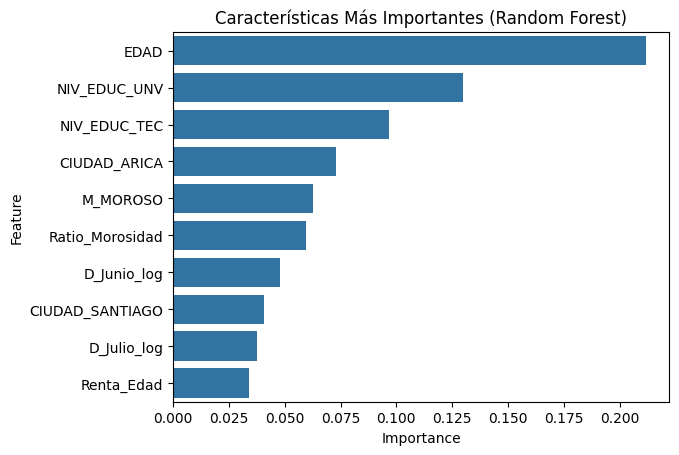

```python
benefit_matrix = {
    'TP': 1000,   # Fuga predicha correctamente (Verdadero positivo)
    'FN': -5000,  # Fuga no predicha (Falso negativo)
    'FP': -100,   # No Fuga predicha como Fuga (Falso positivo)
    'TN': 0       # No Fuga predicha correctamente (Verdadero negativo)
}

# Función para calcular el beneficio total basado en la matriz de confusión
def calcular_beneficio(conf_matrix):
    TP = conf_matrix[1, 1]  # Fuga predicha correctamente
    FN = conf_matrix[1, 0]  # Fuga no predicha
    FP = conf_matrix[0, 1]  # No Fuga predicha como Fuga
    TN = conf_matrix[0, 0]  # No Fuga predicha correctamente

    beneficio_total = (
        TP * benefit_matrix['TP'] +
        FN * benefit_matrix['FN'] +
        FP * benefit_matrix['FP'] +
        TN * benefit_matrix['TN']
    )
    return beneficio_total

# Predicciones de cada modelo
y_pred_log_reg = log_reg.predict(X_test)
y_pred_rf = random_forest.predict(X_test)
y_pred_svm = svm.predict(X_test)

# Matrices de confusión para cada modelo
conf_matrix_log_reg = confusion_matrix(y_test, y_pred_log_reg)
conf_matrix_rf = confusion_matrix(y_test, y_pred_rf)
conf_matrix_svm = confusion_matrix(y_test, y_pred_svm)

# Calcular el beneficio para cada modelo usando la función definida anteriormente
beneficio_log_reg = calcular_beneficio(conf_matrix_log_reg)
beneficio_rf = calcular_beneficio(conf_matrix_rf)
beneficio_svm = calcular_beneficio(conf_matrix_svm)

print("Beneficio de Regresión Logística:", beneficio_log_reg)
print("Beneficio de Random Forest:", beneficio_rf)
print("Beneficio de SVM:", beneficio_svm)

# Importancia de características para el modelo Random Forest
importances = pd.DataFrame({
    'Feature': X_train.columns,
    'Importance': random_forest.feature_importances_
})
importances = importances.sort_values(by='Importance', ascending=False)


sns.barplot(x='Importance', y='Feature', data=importances.head(10))  # Mostrar las 10 más importantes
plt.title("Características Más Importantes (Random Forest)")
plt.show()
```

El análisis de importancia de caracteristica nos mostró de que las dimensiones mas importantes para poder predicir una fuga de clientes son:

1. Edad: Es el predictor mas fuerte, lo que sugiere que ciertos grupos etarios estan mas predispuestos a abandonar el servicio.
2. Nivel educativo: Los niveles educativos universitario (NIV_EDUC_UNV) y técnico (NIV_EDUC_TEC), posiblemente indicando diferencias en expectativas o uso del servicio según la formación académica.
3. Ratio de morosidad: Esta dimension indica el comportamiento de pago de los clientes y sugiere que aquellos con mayor morosidad tienen una mayor probabilidad de fuga.
4. Factores temporales: Variables como D_Julio_log sugieren que algunos patrones de fuga pueden estar relacionados con estacionalidades o eventos específicos del año.

Los resultados obtenidos nos entregan una guía sobre los factores a considerar por la empresa para desarrollar las estrategias de retención, permitiendo obtener los segmentos de clientes que estan mas propensos a fugarse según las caracteristicas clave. Adicional al modelo sugerido, siempre es recomendable hacer un monitoreo periodico para hacer uso de prevencion de fuga.

## 6 Buscando perfil de fugas

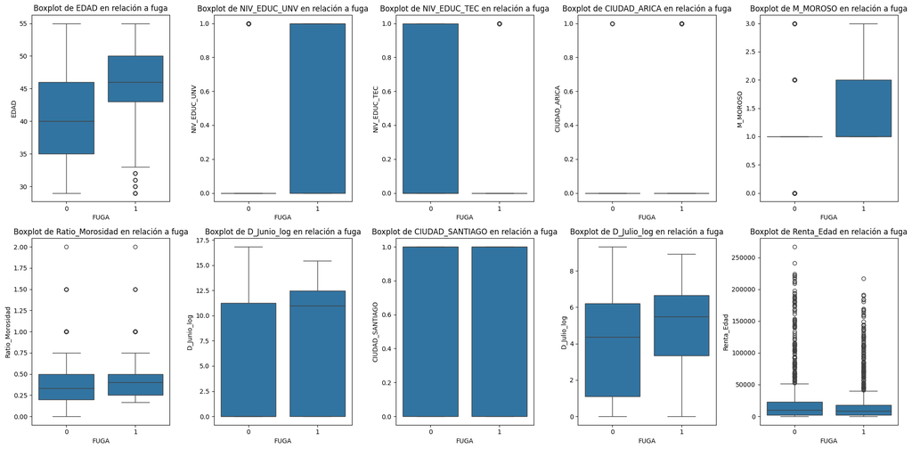

```python
# Obtener las 10 características más importantes
top_features = importances.head(10)['Feature'].tolist()

# Crear subplots para las características importantes
n_cols = 5  # Número de columnas en la figura
n_rows = -(-len(top_features) // n_cols)  # Calcular el número de filas necesario

fig, axes = plt.subplots(n_rows, n_cols, figsize=(20, 5 * n_rows))  # Ajustar ancho

# Ajustar márgenes
plt.subplots_adjust(wspace=0.5, hspace=0.5)  # Ajusta el espacio horizontal y vertical

# Iterar sobre las características y crear los boxplots
for i, feature in enumerate(top_features):
    row = i // n_cols
    col = i % n_cols
    sns.boxplot(x=df['FUGA'], y=df[feature], ax=axes[row, col])
    axes[row, col].set_title(f'Boxplot de {feature} en relación a fuga')

# Ajustar el diseño de la figura para evitar superposiciones
plt.tight_layout()
plt.show()
```

```python
tabla = df.groupby('FUGA').agg({
    'EDAD': ['mean', 'median', 'std'],
    'NIV_EDUC_UNV': ['mean', 'median', 'std'],
    'Ratio_Morosidad': ['mean', 'median', 'std'],
    'NIV_EDUC_TEC': ['mean', 'median', 'std'],
    'D_Julio_log': ['mean', 'median', 'std'],
    'CIUDAD_ARICA': ['mean', 'median', 'std'],
    'Renta_Edad': ['mean', 'median', 'std'],
    'D_Junio_log': ['mean', 'median', 'std'],
    'M_MOROSO': ['mean', 'median', 'std'],
    'Deuda_Renta': ['mean', 'median', 'std'],
}).T

tabla.rename(columns={0:'NO FUGA',1:'FUGA'}, inplace=True)
tabla
```

|  | FUGA | NO FUGA | FUGA |
| --- | --- | --- | --- |
| EDAD | mean | 40.736041 | 46.307834 |
|  | median | 40.000000 | 46.000000 |
|  | std | 7.083085 | 5.296485 |
| NIV_EDUC_UNV | mean | 0.177665 | 0.649770 |
|  | median | 0.000000 | 1.000000 |
|  | std | 0.382425 | 0.477262 |
| Ratio_Morosidad | mean | 0.342420 | 0.433217 |
|  | median | 0.333333 | 0.400000 |
|  | std | 0.282577 | 0.223908 |
| NIV_EDUC_TEC | mean | 0.496447 | 0.113364 |
|  | median | 0.000000 | 0.000000 |
|  | std | 0.500241 | 0.317183 |
| D_Julio_log | mean | 3.896562 | 4.768779 |
|  | median | 4.356709 | 5.484797 |
|  | std | 2.740030 | 2.567794 |
| CIUDAD_ARICA | mean | 0.008122 | 0.204608 |
|  | median | 0.000000 | 0.000000 |
|  | std | 0.089800 | 0.403601 |
| Renta_Edad | mean | 25201.979346 | 18817.402304 |
|  | median | 9732.170732 | 8256.275000 |
|  | std | 42525.732581 | 31760.269874 |
| D_Junio_log | mean | 4.636094 | 7.844861 |
|  | median | 0.000000 | 10.985682 |
|  | std | 5.807498 | 5.719732 |
| M_MOROSO | mean | 1.021320 | 1.506912 |
|  | median | 1.000000 | 1.000000 |
|  | std | 0.746640 | 0.692073 |
| Deuda_Renta | mean | 9.951954 | 13.749339 |
|  | median | 0.791694 | 1.122627 |
|  | std | 52.046694 | 70.082971 |

De los resultados obtenidos podemos concluir esto Clientes que se fugan (FUGA = 1):

Edad: La edad promedio de los clientes que se fugan es mayor (46.3) que la de los que no (40.73).

Nivel educativo: Los clientes que se fugan tienen una probabilidad mayor de tener un nivel educativo universitario (NIV_EDUC_UNV) y una menor probabilidad de tener un nivel educativo técnico (NIV_EDUC_TEC).

Ratio de morosidad: El ratio de morosidad promedio es ligeramente más alto para los clientes que se fugan, pero la diferencia no es tan grande.

Ingresos: Los clientes que se fugan tienden a tener ingresos más bajos (Renta_Edad) que los que no se fugan.

Fechas de pago: Los clientes que se fugan tienden a tener un retraso mayor en los pagos de los meses de junio y julio (D_Junio_log y D_Julio_log).

Morosidad: La morosidad promedio (M_MOROSO) es mayor para los clientes que se fugan.

Clientes que NO se fugan (FUGA = 0):

Edad: La edad promedio de los clientes que NO se fugan es menor que la de los que sí se fugan.

Nivel educativo: Los clientes que NO se fugan tienen una probabilidad mayor de tener un nivel educativo técnico y una menor probabilidad de tener un nivel educativo universitario.

Ingresos: Los clientes que NO se fugan tienden a tener ingresos más altos.

Fechas de pago: Los clientes que NO se fugan tienden a tener menos retraso en los pagos de los meses de junio y julio.

Morosidad: La morosidad promedio es menor para los clientes que NO se fugan.

Análisis de los patrones:

Objetivo Reducir la tasa de pérdida de clientes, fomentar la lealtad y asegurar un crecimiento sostenible para el negocio. Principios Rectores

```
Conocer al Cliente a Fondo
Comprender las necesidades, preferencias y comportamientos de nuestros clientes para ofrecer soluciones ajustadas a su perfil.

Prevención Activa
Implementar acciones anticipadas para evitar la fuga, identificando y abordando posibles necesidades o problemas de los clientes.

Relación a Largo Plazo
Desarrollar una relación sólida y confiable con los clientes, basada en transparencia y satisfacción.
```

Estrategias Principales

```
Segmentación de Clientes

    Identificación de Grupos de Riesgo
    Clasificar a los clientes en niveles de riesgo (alto, medio y bajo) basándose en datos como edad, ingresos, historial de pagos y otros factores relevantes.

    Acciones Personalizadas
    Diseñar programas específicos para cada grupo, con especial atención en aquellos con alto riesgo de fuga.

Fidelización de Clientes

    Programas de Recompensas
    Ofrecer beneficios a los clientes con bajo riesgo, incentivando su permanencia con descuentos, servicios exclusivos o programas de puntos.

    Atención Personalizada
    Capacitar al equipo para brindar un servicio excepcional, enfocado en soluciones que respondan a las necesidades individuales, especialmente de aquellos clientes con alto riesgo de fuga.

Gestión de la Deuda

    Planes de Pago Flexibles
    Facilitar opciones de pago a clientes en situación financiera complicada, evitando acumulación de deuda que pueda llevar a su salida.

    Educación Financiera
    Brindar herramientas y recursos educativos para que los clientes gestionen mejor sus finanzas y reduzcan el riesgo de morosidad.

    Transparencia en Tarifas
    Garantizar que todos los costos y términos sean claros, evitando sorpresas en comisiones o tarifas.

Comunicación Estratégica

    Comunicación Proactiva
    Mantener un contacto frecuente con los clientes en riesgo de fuga, ofreciéndoles apoyo y soluciones de valor.

    Mensajes Personalizados
    Adaptar los mensajes a las características y necesidades de cada cliente, basándose en su historial y comportamiento.

    Uso de Canales Preferidos
    Utilizar los canales de comunicación que cada cliente prefiera (correo, mensaje de texto, redes sociales, entre otros).

Monitoreo y Evaluación

    Seguimiento de la Tasa de Fuga
    Evaluar de manera continua la tasa de salida para medir la efectividad de nuestras estrategias de retención.

    Análisis de las Causas de Fuga
    Identificar las razones por las que algunos clientes abandonan, para ajustar y mejorar las estrategias.

    Evaluación de la Satisfacción
    Realizar encuestas periódicas para detectar áreas de mejora en la satisfacción del cliente.
```

Implementación

```
Asignación de Recursos
Proveer los recursos necesarios, tales como capacitación, herramientas tecnológicas y programas de fidelización, para asegurar una correcta implementación.

Comunicación Interna
Informar a todos los empleados sobre esta política para lograr un enfoque coherente en la atención al cliente.

Monitoreo y Adaptación
Revisar los resultados y ajustar las estrategias según sea necesario para mejorar continuamente.
```

Beneficios Esperados

```
Reducción de la Tasa de Fuga
Aumentar la retención de clientes y asegurar un flujo de ingresos constante.

Incremento en la Fidelización
Fortalecer la relación con los clientes, promoviendo la lealtad hacia la marca.

Crecimiento Sostenible
Impulsar el crecimiento mediante la retención de clientes y reducir costos asociados a la captación de nuevos usuarios.
```

```python
X_train.columns
```

```
Index(['NIV_EDUC_EUN', 'NIV_EDUC_MED', 'NIV_EDUC_TEC', 'NIV_EDUC_UNV',
       'CIUDAD_ANGOL', 'CIUDAD_ANTOFAGASTA', 'CIUDAD_ARICA', 'CIUDAD_AYSEN',
       'CIUDAD_CALAMA', 'CIUDAD_CALBUCO', 'CIUDAD_CALDERA', 'CIUDAD_CASTRO',
       'CIUDAD_CHILLAN', 'CIUDAD_CHUQUICAMATA', 'CIUDAD_CONCEPCION',
       'CIUDAD_COPIAPO', 'CIUDAD_COQUIMBO', 'CIUDAD_CORONEL',
       'CIUDAD_COYHAIQUE', 'CIUDAD_CURICO', 'CIUDAD_EL SALVADOR',
       'CIUDAD_HIJUELAS', 'CIUDAD_HUASCO', 'CIUDAD_IQUIQUE',
       'CIUDAD_LA CALERA', 'CIUDAD_LA CRUZ', 'CIUDAD_LA SERENA',
       'CIUDAD_LINARES', 'CIUDAD_LLANQUIHUE', 'CIUDAD_LLO-LLEO',
       'CIUDAD_LONCOCHE', 'CIUDAD_LOS ANDES', 'CIUDAD_LOS ANGELES',
       'CIUDAD_LOS LAGOS', 'CIUDAD_LOS VILOS', 'CIUDAD_MACHALI',
       'CIUDAD_MELIPILLA', 'CIUDAD_OSORNO', 'CIUDAD_OVALLE', 'CIUDAD_PALENA',
       'CIUDAD_PANGUIPULLI', 'CIUDAD_PARRAL', 'CIUDAD_PENCO', 'CIUDAD_PETORCA',
       'CIUDAD_PUERTO MONTT', 'CIUDAD_PUERTO OCTAY', 'CIUDAD_PUERTO VARAS',
       'CIUDAD_PUNTA ARENAS', 'CIUDAD_QUILLOTA', 'CIUDAD_QUILPUE',
       'CIUDAD_RANCAGUA', 'CIUDAD_RENGO', 'CIUDAD_SAN ANTONIO',
       'CIUDAD_SAN CLEMENTE', 'CIUDAD_SAN ESTEBAN', 'CIUDAD_SAN FELIPE',
       'CIUDAD_SAN FERNANDO', 'CIUDAD_SAN PEDRO', 'CIUDAD_SANTA CRUZ',
       'CIUDAD_SANTIAGO', 'CIUDAD_STO DOMINGO', 'CIUDAD_TALAGANTE',
       'CIUDAD_TALCA', 'CIUDAD_TALCAHUANO', 'CIUDAD_TEMUCO',
       'CIUDAD_TOCOPILLA', 'CIUDAD_VALDIVIA', 'CIUDAD_VALLENAR',
       'CIUDAD_VALPARAISO', 'CIUDAD_VILLARRICA', 'CIUDAD_VINA DEL MAR',
       'CIUDAD_VLLA ALEMANA', 'EDAD', 'M_MOROSO', 'D_Julio_log', 'D_Junio_log',
       'Promedio_Deuda', 'Ratio_Morosidad', 'Renta_Edad',
       'Endeudamiento_Total', 'Deuda_Renta', 'Variabilidad_Deuda'],
      dtype='object')
```

```python
data_validacion = data_validacion.dropna(subset=[col for col in data_validacion if col != 'FUGA'])
```

```python
# Creamos indicadores, nuevas variables en el dataset limpio que nos pueden ayudar a entener tendencias

# 1. Promedio de deudas mensuales
data_validacion['Promedio_Deuda'] = data_validacion[['D_Marzo', 'D_Abril', 'D_Mayo', 'D_Junio', 'D_Julio', 'D_Agosto', 'D_Septiembre']].mean(axis=1)

# 2. Ratio de morosidad (número de veces en mora / número de meses con deuda)
months_with_debt = (data_validacion[['D_Marzo', 'D_Abril', 'D_Mayo', 'D_Junio', 'D_Julio', 'D_Agosto', 'D_Septiembre']] > 0).sum(axis=1)
data_validacion['Ratio_Morosidad'] = data_validacion['M_MOROSO'] / months_with_debt.replace(0, 1)

# 3. Renta por Edad
data_validacion['Renta_Edad'] = data_validacion['RENTA'] / data_validacion['EDAD'].replace(0, 1)

# 4. Endeudamiento Total (Suma de las deudas mensuales)
data_validacion['Endeudamiento_Total'] = data_validacion[['D_Marzo', 'D_Abril', 'D_Mayo', 'D_Junio', 'D_Julio', 'D_Agosto', 'D_Septiembre']].sum(axis=1)

# 5. Deuda respecto a Renta
data_validacion['Deuda_Renta'] = data_validacion['Endeudamiento_Total'] / data_validacion['RENTA'].replace(0, 1)

# 6. Variabilidad de deudas (Desviación estándar de las deudas mensuales)
data_validacion['Variabilidad_Deuda'] = data_validacion[['D_Marzo', 'D_Abril', 'D_Mayo', 'D_Junio', 'D_Julio', 'D_Agosto', 'D_Septiembre']].std(axis=1)

# Mostrar las primeras filas con las nuevas variables
data_validacion[['Promedio_Deuda', 'Ratio_Morosidad', 'Renta_Edad', 'Endeudamiento_Total', 'Deuda_Renta', 'Variabilidad_Deuda']].head()
```

|  | Promedio_Deuda | Ratio_Morosidad | Renta_Edad | Endeudamiento_Total | Deuda_Renta | Variabilidad_Deuda |
| --- | --- | --- | --- | --- | --- | --- |
| 0 | 30200.285714 | 0.333333 | 10170.955556 | 211402 | 0.461886 | 71129.808006 |
| 1 | 6765.142857 | 0.000000 | 75279.400000 | 47356 | 0.020969 | 17898.003682 |
| 2 | 136624.714286 | 0.200000 | 10709.607843 | 956373 | 1.750990 | 235680.658781 |
| 3 | 56701.142857 | 0.750000 | 10351.804878 | 396908 | 0.935169 | 148238.819900 |
| 4 | 50335.857143 | 0.250000 | 163398.238095 | 352351 | 0.051343 | 99878.840723 |

```python
#scaler = MinMaxScaler()
# aplicamos el método

columns_to_exclude = ['ID', 'M_MOROSO','COD_COM','COD_OFI','EDAD']
numeric_columns = data_validacion.select_dtypes(include=['float', 'int64']).columns.difference(columns_to_exclude)

for column in numeric_columns:
    # Agrega 1 a los valores para evitar el logaritmo de cero
    data_validacion[column+'_log'] = np.log1p(data_validacion[column])

#data_validacion[data_validacion._get_numeric_data().columns] = scaler.fit_transform(data_validacion[data_validacion._get_numeric_data().columns])

df_encoded = pd.get_dummies(data_validacion, columns=['NIV_EDUC','CIUDAD'], drop_first=True)

categorical_columns  = df_encoded.select_dtypes(include=['bool']).columns.tolist()
selected_columns = categorical_columns + ['EDAD','M_MOROSO','D_Julio_log','D_Junio_log','FUGA','Promedio_Deuda', 'Ratio_Morosidad', 'Renta_Edad', 'Endeudamiento_Total', 'Deuda_Renta', 'Variabilidad_Deuda']

df_validacion = df_encoded[selected_columns]
```

```python
df_validacion = df_validacion.dropna(subset=[col for col in df_validacion if col != 'FUGA'])
```

```python
cols_create = ['CIUDAD_ANGOL', 'CIUDAD_CALDERA', 'CIUDAD_CORONEL', 'CIUDAD_HUASCO', 'CIUDAD_LLANQUIHUE', 'CIUDAD_LOS LAGOS', 'CIUDAD_LOS VILOS', 'CIUDAD_PALENA', 'CIUDAD_PARRAL', 'CIUDAD_PETORCA', 'CIUDAD_PUERTO OCTAY', 'CIUDAD_SAN ANTONIO', 'CIUDAD_SAN FELIPE', 'CIUDAD_SANTA CRUZ', 'CIUDAD_TALAGANTE', 'CIUDAD_VALLENAR', 'CIUDAD_VLLA ALEMANA']

for i in cols_create:
  df_validacion[i] = False
```

```python
df_validacion = df_validacion[['NIV_EDUC_EUN', 'NIV_EDUC_MED', 'NIV_EDUC_TEC', 'NIV_EDUC_UNV',
       'CIUDAD_ANGOL', 'CIUDAD_ANTOFAGASTA', 'CIUDAD_ARICA', 'CIUDAD_AYSEN',
       'CIUDAD_CALAMA', 'CIUDAD_CALBUCO', 'CIUDAD_CALDERA', 'CIUDAD_CASTRO',
       'CIUDAD_CHILLAN', 'CIUDAD_CHUQUICAMATA', 'CIUDAD_CONCEPCION',
       'CIUDAD_COPIAPO', 'CIUDAD_COQUIMBO', 'CIUDAD_CORONEL',
       'CIUDAD_COYHAIQUE', 'CIUDAD_CURICO',
       'CIUDAD_EL SALVADOR', 'CIUDAD_HIJUELAS', 'CIUDAD_HUASCO',
       'CIUDAD_IQUIQUE', 'CIUDAD_LA CALERA', 'CIUDAD_LA CRUZ',
       'CIUDAD_LA SERENA', 'CIUDAD_LINARES', 'CIUDAD_LLANQUIHUE',
       'CIUDAD_LLO-LLEO', 'CIUDAD_LONCOCHE', 'CIUDAD_LOS ANDES',
       'CIUDAD_LOS ANGELES', 'CIUDAD_LOS LAGOS', 'CIUDAD_LOS VILOS',
       'CIUDAD_MACHALI', 'CIUDAD_MELIPILLA', 'CIUDAD_OSORNO', 'CIUDAD_OVALLE',
       'CIUDAD_PALENA', 'CIUDAD_PANGUIPULLI', 'CIUDAD_PARRAL', 'CIUDAD_PENCO',
       'CIUDAD_PETORCA', 'CIUDAD_PUERTO MONTT', 'CIUDAD_PUERTO OCTAY',
       'CIUDAD_PUERTO VARAS', 'CIUDAD_PUNTA ARENAS', 'CIUDAD_QUILLOTA',
       'CIUDAD_QUILPUE', 'CIUDAD_RANCAGUA', 'CIUDAD_RENGO',
       'CIUDAD_SAN ANTONIO', 'CIUDAD_SAN CLEMENTE', 'CIUDAD_SAN ESTEBAN',
       'CIUDAD_SAN FELIPE', 'CIUDAD_SAN FERNANDO', 'CIUDAD_SAN PEDRO',
       'CIUDAD_SANTA CRUZ', 'CIUDAD_SANTIAGO', 'CIUDAD_STO DOMINGO',
       'CIUDAD_TALAGANTE', 'CIUDAD_TALCA', 'CIUDAD_TALCAHUANO',
       'CIUDAD_TEMUCO', 'CIUDAD_TOCOPILLA', 'CIUDAD_VALDIVIA',
       'CIUDAD_VALLENAR', 'CIUDAD_VALPARAISO', 'CIUDAD_VILLARRICA',
       'CIUDAD_VINA DEL MAR', 'CIUDAD_VLLA ALEMANA', 'EDAD', 'M_MOROSO',
       'D_Julio_log', 'D_Junio_log','Promedio_Deuda', 'Ratio_Morosidad', 'Renta_Edad', 'Endeudamiento_Total', 'Deuda_Renta', 'Variabilidad_Deuda']]

y_pred_new = svm.predict(df_validacion)
y_proba_new = svm.predict_proba(df_validacion)[:,1]
```

```python
unique, counts = np.unique(y_pred_new, return_counts=True)
predictions_summary = dict(zip(unique, counts))

label_mapping = {0: "no fuga", 1: "fuga"}

# Crear un nuevo diccionario aplicando el mapeo
predictions_summary_descriptive = {label_mapping[key]: value for key, value in predictions_summary.items()}

print("Resumen de predicciones:", predictions_summary_descriptive)
```

```
Resumen de predicciones: {'no fuga': 481, 'fuga': 669}
```

## 7 Conclusiones

Este proyecto tuvo como propósito crear un modelo de machine learning que anticipe la fuga de clientes, permitiendo optimizar los esfuerzos de retención mediante la identificación de aquellos en mayor riesgo. A continuación, se presenta un resumen de los puntos clave y hallazgos obtenidos. Preparación de los Datos

Este proyecto proporciona una herramienta valiosa para la toma de decisiones orientada a reducir la fuga de clientes y optimizar los recursos de retención en función de los perfiles identificados.

```python
df_validacion['FUGA'] = y_pred_new
df_validacion['FUGA'] = df_validacion['FUGA'].map(label_mapping)
df_validacion.to_csv('modelo.csv',index=False)
```